# **Laboratorio 1 - AlpesHearth: Predicción de Riesgo Cardiovascular**

### Estudiante 1: Angel Peñaranda - 202215646

### Estudiante 2: Andrés Alfonso - 202210412

Fecha: 16 de Febrero 2026  
Curso: Aprendizaje de Máquina - ISIS2611

# Introducción

## Contexto del Problema

Las enfermedades cardiovasculares (ECV) causan más de 20,5 millones de muertes cada año en el mundo, según la World Heart Federation, de las cuales el 80% son evitables. AlpesHearth busca reducir esta cifra promoviendo cambios en el estilo de vida.

Entre los 20 y 25 años se consolidan hábitos poco saludables que incrementan el riesgo, como el sedentarismo, la mala alimentación, el consumo de alcohol y tabaco, el estrés crónico y la privación de sueño.

## Objetivos

Los objetivos son construir un modelo predictivo para estimar el CVD Risk Score, determinar los principales factores de riesgo cardiovascular, aplicar regresión lineal, reconocer sesgos del modelo y comunicar resultados claramente.

Este notebook estara compuesto de las siguientes partes:

1. Importacion de librerias
2. Carga de los datos
3. Limpieza inicial de datos
4. Particion de los datos en entrenamiento y test
5. Modelo 1: Regresion lineal basica
6. Modelo 2: Regresion lineal con pipeline completo
7. Estimacion de la capacidad de generalizacion
8. Verificacion de supuestos de regresion lineal
9. Correccion con WLS
10. Regresion robusta (Tukey)
11. Uso del modelo y predicciones
12. Analisis de resultados
13. Conclusiones y recomendaciones

## 1. Importacion de las librerias

```python
# Librerias para manejo de datos
import pandas as pd
import numpy as np
import warnings
warnings.filterwarnings('ignore')

pd.set_option('display.max_columns', 30)
pd.set_option('display.width', 1000)

# Visualizacion
import matplotlib.pyplot as plt
import seaborn as sns
plt.style.use('seaborn-v0_8-whitegrid')
%matplotlib inline
plt.rcParams['figure.figsize'] = (12, 6)

# Machine Learning
from sklearn.model_selection import train_test_split
from sklearn.linear_model import LinearRegression, Ridge
from sklearn.preprocessing import StandardScaler, OneHotEncoder, FunctionTransformer
from sklearn.impute import SimpleImputer
from sklearn.compose import ColumnTransformer
from sklearn.pipeline import Pipeline
from sklearn.metrics import mean_squared_error, mean_absolute_error, r2_score

# Analisis estadistico
from scipy import stats
import statsmodels.api as sm
from statsmodels.stats.outliers_influence import variance_inflation_factor
from statsmodels.stats.stattools import durbin_watson
from statsmodels.stats.diagnostic import linear_rainbow

print("Librerias importadas correctamente")
```

```
Librerias importadas correctamente
```

## 2. Carga de los Datos

IMPORTANTE: Ajustar las rutas segun la ubicacion de tus archivos.

```python
# Cargar datos
train_df = pd.read_csv('Datos Lab 1.csv')
test_df = pd.read_csv('Datos Test Lab 1.csv', sep=';')

print(f"Train: {train_df.shape[0]:,} filas × {train_df.shape[1]} columnas")
print(f"Test: {test_df.shape[0]:,} filas × {test_df.shape[1]} columnas")
print("Datos cargados correctamente")
```

```
Train: 1,639 filas × 24 columnas
Test: 194 filas × 22 columnas
Datos cargados correctamente
```

### 2.1 Vista Previa

```python
train_df.head(10)
```

|  | Patient ID | Date of Service | Sex | Age | Weight (kg) | Height (m) | BMI | Abdominal Circumference (cm) | Blood Pressure (mmHg) | Total Cholesterol (mg/dL) | HDL (mg/dL) | Fasting Blood Sugar (mg/dL) | Smoking Status | Diabetes Status | Physical Activity Level | Family History of CVD | Height (cm) | Waist-to-Height Ratio | Systolic BP | Diastolic BP | Blood Pressure Category | Estimated LDL (mg/dL) | CVD Risk Score | CVD Risk Level |
| --- | --- | --- | --- | --- | --- | --- | --- | --- | --- | --- | --- | --- | --- | --- | --- | --- | --- | --- | --- | --- | --- | --- | --- | --- |
| 0 | isDx5313 | November 08, 2023 | M | 44.000 | 114.300 | 1.720 | 38.600 | 100.000 | 112/83 | 228.0 | 77.0 | 91.0 | Y | Y | High | N | 172.000 | 0.581 | 112.0 | 83.0 | Hypertension Stage 1 | 121.0 | 19.880 | HIGH |
| 1 | LHCK2961 | 20/03/2024 | F | 57.000 | 92.923 | 1.842 | 33.116 | 106.315 | 101/91 | 158.0 | 71.0 | 76.0 | N | Y | High | Y | 184.172 | 0.577 | 101.0 | 91.0 | Hypertension Stage 2 | 57.0 | 16.833 | INTERMEDIARY |
| 2 | WjVn1699 | 2021-05-27 | F | NaN | 73.400 | 1.650 | 27.000 | 78.100 | 90/74 | 135.0 | 60.0 | 150.0 | N | N | High | N | 165.000 | 0.473 | 90.0 | 74.0 | Normal | 45.0 | 12.600 | LOW |
| 3 | dCDO1109 | April 18, 2022 | F | 35.000 | 113.300 | 1.780 | 35.800 | 79.600 | 92/89 | 158.0 | 34.0 | 111.0 | Y | N | Moderate | Y | 178.000 | 0.447 | 92.0 | 89.0 | Hypertension Stage 1 | 94.0 | 14.920 | HIGH |
| 4 | pnpE1080 | 01/11/2024 | F | 48.000 | 102.200 | 1.750 | 33.400 | 106.700 | 121/68 | 207.0 | 49.0 | 147.0 | Y | Y | Low | Y | 175.000 | 0.610 | 121.0 | 68.0 | Elevated | 128.0 | 18.870 | HIGH |
| 5 | MQyB2747 | 25 Mar 24 | M | 43.000 | 52.700 | 1.850 | 15.400 | 107.700 | 107/61 | 105.0 | 32.0 | 70.0 | Y | N | High | N | 185.000 | 0.582 | 107.0 | 61.0 | Normal | 43.0 | 10.530 | INTERMEDIARY |
| 6 | DHdn8968 | 22 May 25 | F | 31.000 | 87.000 | 1.660 | 31.600 | 91.500 | 139/81 | 207.0 | 56.0 | 82.0 | N | N | Low | Y | 166.000 | 0.551 | 139.0 | 81.0 | Hypertension Stage 1 | 121.0 | 17.410 | HIGH |
| 7 | vkQL9700 | October 26, 2023 | M | 69.000 | 59.684 | 1.940 | 23.914 | 117.986 | 106/115 | 206.0 | 42.0 | 140.0 | Y | Y | High | Y | 193.981 | 0.608 | 106.0 | 115.0 | Hypertension Stage 2 | 134.0 | 16.203 | HIGH |
| 8 | bUBT9994 | 15/12/2023 | F | 89.162 | 85.600 | 1.660 | 31.100 | 83.600 | 103/99 | 222.0 | 66.0 | 99.0 | Y | Y | High | N | 166.000 | 0.504 | 103.0 | 99.0 | Hypertension Stage 2 | 126.0 | NaN | HIGH |
| 9 | nktq6689 | January 16, 2022 | F | 57.000 | 100.130 | 1.840 | 22.242 | 80.814 | 165/99 | 123.0 | 54.0 | 94.0 | N | N | Low | N | 183.988 | 0.439 | 165.0 | 99.0 | Hypertension Stage 2 | 39.0 | 15.158 | LOW |

### 2.2 Informacion General

```python
print("Columnas del dataset:")
for i, col in enumerate(train_df.columns, 1):
    print(f"  {i:2d}. {col}")

print(f"\nTipos de datos:\n{train_df.dtypes.value_counts()}")

print(f"Shape: {train_df.shape}")
print(f"Columnas: {train_df.columns.tolist()}")
print("\nPrimeras 3 filas sin procesar:")
print(train_df.head(3))
```

```
Columnas del dataset:
   1. Patient ID
   2. Date of Service
   3. Sex
   4. Age
   5. Weight (kg)
   6. Height (m)
   7. BMI
   8. Abdominal Circumference (cm)
   9. Blood Pressure (mmHg)
  10. Total Cholesterol (mg/dL)
  11. HDL (mg/dL)
  12. Fasting Blood Sugar (mg/dL)
  13. Smoking Status
  14. Diabetes Status
  15. Physical Activity Level
  16. Family History of CVD
  17. Height (cm)
  18. Waist-to-Height Ratio
  19. Systolic BP
  20. Diastolic BP
  21. Blood Pressure Category
  22. Estimated LDL (mg/dL)
  23. CVD Risk Score
  24. CVD Risk Level

Tipos de datos:
float64    14
str        10
Name: count, dtype: int64
Shape: (1639, 24)
Columnas: ['Patient ID', 'Date of Service', 'Sex', 'Age', 'Weight (kg)', 'Height (m)', 'BMI', 'Abdominal Circumference (cm)', 'Blood Pressure (mmHg)', 'Total Cholesterol (mg/dL)', 'HDL (mg/dL)', 'Fasting Blood Sugar (mg/dL)', 'Smoking Status', 'Diabetes Status', 'Physical Activity Level', 'Family Hi…

Primeras 3 filas sin procesar:
  Patient ID    Date of Service Sex   Age  Weight (kg)  Height (m)     BMI  Abdominal Circumference (cm) Blood Pressure (mmHg)  Total Cholesterol (mg/dL)  HDL (mg/dL)  Fasting Blood Sugar (mg/dL) Smoking Status Diabetes Status Physical Activity Level Family History of CVD  Height (cm)  Waist-to-Heig…
0   isDx5313  November 08, 2023   M  44.0      114.300       1.720  38.600                       100.000                112/83                      228.0         77.0                         91.0              Y               Y                    High                     N      172.000               …
1   LHCK2961         20/03/2024   F  57.0       92.923       1.842  33.116                       106.315                101/91                      158.0         71.0                         76.0              N               Y                    High                     Y      184.172               …
2   WjVn1699         2021-05-27   F   NaN       73.400       1.650  27.000                        78.100                 90/74                      135.0         60.0                        150.0              N               N                    High                     N      165.000               …
```

## 3. Limpieza inicial de datos

### 3.1 Estadisticas Descriptivas

#### 3.1.1 Variables Numericas

```python
# Estadísticas descriptivas de variables numéricas
train_df.describe()
```

|  | Age | Weight (kg) | Height (m) | BMI | Abdominal Circumference (cm) | Total Cholesterol (mg/dL) | HDL (mg/dL) | Fasting Blood Sugar (mg/dL) | Height (cm) | Waist-to-Height Ratio | Systolic BP | Diastolic BP | Estimated LDL (mg/dL) | CVD Risk Score |
| --- | --- | --- | --- | --- | --- | --- | --- | --- | --- | --- | --- | --- | --- | --- |
| count | 1571.000000 | 1566.000000 | 1578.000000 | 1586.000000 | 1578.000000 | 1571.000000 | 1557.000000 | 1585.000000 | 1571.000000 | 1563.000000 | 1578.000000 | 1554.000000 | 1582.000000 | 1610.000000 |
| mean | 46.803186 | 85.666006 | 1.757439 | 28.424744 | 91.538861 | 199.043673 | 56.183558 | 117.836860 | 175.770082 | 0.522440 | 125.632637 | 82.887536 | 113.235896 | 18.227281 |
| std | 13.039479 | 21.712504 | 0.118012 | 7.309275 | 13.427985 | 59.388670 | 16.721702 | 32.379634 | 11.695880 | 0.085692 | 22.577463 | 15.503625 | 61.435291 | 10.767666 |
| min | 6.134000 | 13.261000 | 1.371000 | 4.317000 | 49.542000 | -1.256000 | 0.008000 | 15.306000 | 136.498000 | 0.250000 | 49.914000 | 31.720000 | -92.055000 | -20.057000 |
| 25% | 37.000000 | 67.100000 | 1.666500 | 22.600000 | 79.700000 | 150.000000 | 42.000000 | 92.000000 | 167.000000 | 0.453000 | 108.000000 | 71.000000 | 62.000000 | 15.150000 |
| 50% | 46.000000 | 86.314000 | 1.760000 | 28.000000 | 91.200000 | 199.000000 | 56.000000 | 115.000000 | 176.000000 | 0.519000 | 125.000000 | 82.000000 | 112.000000 | 16.967000 |
| 75% | 55.000000 | 104.801500 | 1.850000 | 33.963000 | 102.267250 | 250.000000 | 70.000000 | 139.000000 | 185.000000 | 0.582000 | 141.000000 | 93.000000 | 159.000000 | 18.900000 |
| max | 89.420000 | 158.523000 | 2.146000 | 53.028000 | 136.336000 | 385.679000 | 110.315000 | 219.667000 | 214.394000 | 0.804000 | 202.711000 | 134.066000 | 317.314000 | 114.980000 |

#### 3.1.2 Variable Objetivo

```
============================================================
ANÁLISIS DE CVD RISK SCORE (Variable Objetivo)
============================================================
Tipo: float64
Valores únicos: 1119
Valores nulos: 29

Estadísticas:
count    1610.000000
mean       18.227281
std        10.767666
min       -20.057000
25%        15.150000
50%        16.967000
75%        18.900000
max       114.980000
Name: CVD Risk Score, dtype: float64
```

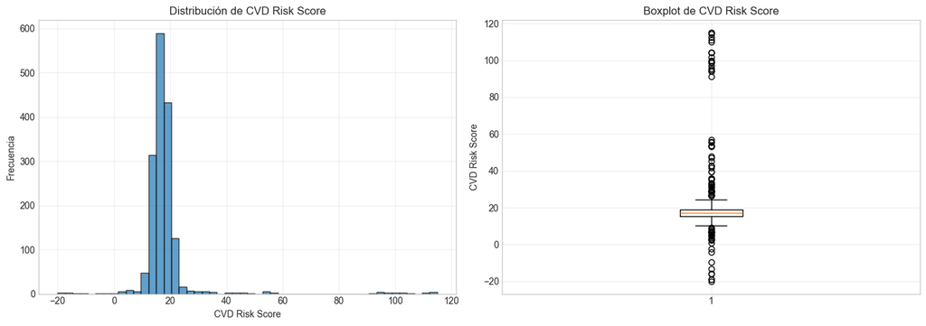

```python
# Análisis de la variable objetivo
print("="*60)
print("ANÁLISIS DE CVD RISK SCORE (Variable Objetivo)")
print("="*60)
print(f"Tipo: {train_df['CVD Risk Score'].dtype}")
print(f"Valores únicos: {train_df['CVD Risk Score'].nunique()}")
print(f"Valores nulos: {train_df['CVD Risk Score'].isna().sum()}")
print(f"\nEstadísticas:")
print(train_df['CVD Risk Score'].describe())

# Visualización
fig, axes = plt.subplots(1, 2, figsize=(14, 5))

# Histograma
axes[0].hist(train_df['CVD Risk Score'].dropna(), bins=50, edgecolor='black', alpha=0.7)
axes[0].set_xlabel('CVD Risk Score')
axes[0].set_ylabel('Frecuencia')
axes[0].set_title('Distribución de CVD Risk Score')
axes[0].grid(True, alpha=0.3)

# Boxplot
axes[1].boxplot(train_df['CVD Risk Score'].dropna(), vert=True)
axes[1].set_ylabel('CVD Risk Score')
axes[1].set_title('Boxplot de CVD Risk Score')
axes[1].grid(True, alpha=0.3)

plt.tight_layout()
plt.show()
```

#### 3.1.3 Variables Categoricas

```python
# Análisis de variables categóricas
cat_cols = train_df.select_dtypes(include='object').columns
print(f"Variables categóricas encontradas: {len(cat_cols)}")
print(f"\nColumnas: {list(cat_cols)}")

for col in cat_cols:
    if col != 'Patient ID' and col != 'Date of Service':
        unique_vals = train_df[col].nunique()
        print(f"\n{col}: {unique_vals} valores únicos")
        if unique_vals <= 10:
            print(train_df[col].value_counts())
```

```
Variables categóricas encontradas: 10

Columnas: ['Patient ID', 'Date of Service', 'Sex', 'Blood Pressure (mmHg)', 'Smoking Status', 'Diabetes Status', 'Physical Activity Level', 'Family History of CVD', 'Blood Pressure Category', 'CVD Risk Level']

Sex: 2 valores únicos
Sex
M    821
F    818
Name: count, dtype: int64

Blood Pressure (mmHg): 1152 valores únicos

Smoking Status: 2 valores únicos
Smoking Status
Y    850
N    789
Name: count, dtype: int64

Diabetes Status: 2 valores únicos
Diabetes Status
N    821
Y    818
Name: count, dtype: int64

Physical Activity Level: 3 valores únicos
Physical Activity Level
High        582
Moderate    537
Low         520
Name: count, dtype: int64

Family History of CVD: 2 valores únicos
Family History of CVD
N    820
Y    819
Name: count, dtype: int64

Blood Pressure Category: 4 valores únicos
Blood Pressure Category
Hypertension Stage 2    680
Hypertension Stage 1    527
Normal                  321
Elevated                111
Name: count, dtype: int64

CVD Risk Level: 3 valores únicos
CVD Risk Level
HIGH            793
INTERMEDIARY    616
LOW             230
Name: count, dtype: int64
```

### 3.2 Analisis de Calidad de Datos

Analizaremos cuatro aspectos clave de calidad: completitud (valores faltantes), duplicidad (registros duplicados), consistencia (valores coherentes) y validez (tipos de datos correctos).

#### 3.2.1 Completitud (Valores Faltantes)

```
======================================================================
ANÁLISIS DE VALORES FALTANTES
======================================================================
                     Columna  Valores Nulos  Porcentaje (%)
                Diastolic BP             85        5.186089
                 HDL (mg/dL)             82        5.003051
       Waist-to-Height Ratio             76        4.636974
                 Weight (kg)             73        4.453935
   Total Cholesterol (mg/dL)             68        4.148871
                         Age             68        4.148871
                 Height (cm)             68        4.148871
                 Systolic BP             61        3.721782
                  Height (m)             61        3.721782
Abdominal Circumference (cm)             61        3.721782
       Estimated LDL (mg/dL)             57        3.477730
 Fasting Blood Sugar (mg/dL)             54        3.294692
                         BMI             53        3.233679
              CVD Risk Score             29        1.769372
```

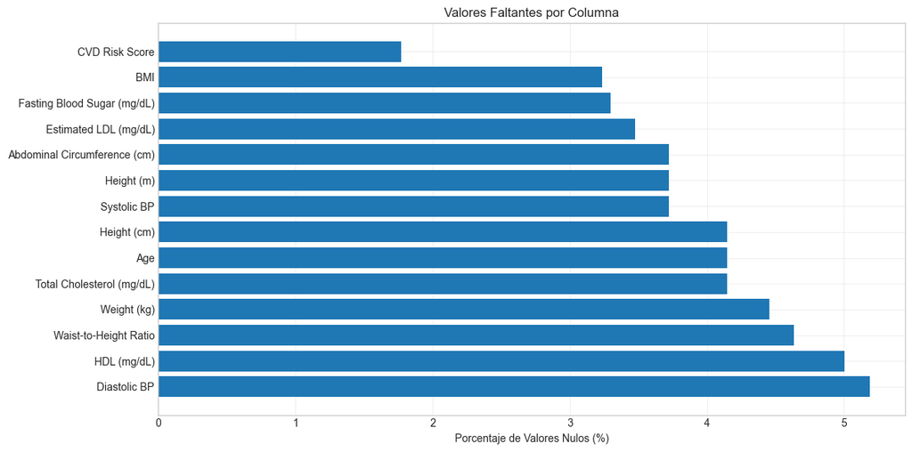

```python
# Análisis de valores faltantes
null_counts = train_df.isnull().sum()
null_pct = (null_counts / len(train_df)) * 100
null_df = pd.DataFrame({
    'Columna': null_counts.index,
    'Valores Nulos': null_counts.values,
    'Porcentaje (%)': null_pct.values
})
null_df = null_df[null_df['Valores Nulos'] > 0].sort_values('Valores Nulos', ascending=False)

print("="*70)
print("ANÁLISIS DE VALORES FALTANTES")
print("="*70)
print(null_df.to_string(index=False))

# Visualización
if len(null_df) > 0:
    plt.figure(figsize=(12, 6))
    plt.barh(null_df['Columna'], null_df['Porcentaje (%)'])
    plt.xlabel('Porcentaje de Valores Nulos (%)')
    plt.title('Valores Faltantes por Columna')
    plt.grid(True, alpha=0.3)
    plt.tight_layout()
    plt.show()
else:
    print("\n No hay valores faltantes en el dataset")
```

Análisis y Decisiones:

Para las variables con valores faltantes, debemos decidir entre imputar con media, mediana, moda o valores relacionados, eliminar si son muy pocos o no son críticos, o crear un indicador binario que señale si faltaba el dato.

Según el enunciado, ya se han llenado algunos valores con relación lógica: blood pressure usando sistólicas/diastólicas, BMI usando peso y altura, y circunferencia abdominal con datos relacionados.

#### 3.2.2 Duplicidad

```python
# Análisis de duplicados
duplicados = train_df.duplicated().sum()
print(f"Registros duplicados: {duplicados}")

if duplicados > 0:
    print(f"\nSe encontraron {duplicados} registros duplicados")
    print("\nPrimeros duplicados:")
    print(train_df[train_df.duplicated(keep=False)].head())
else:
    print("No hay registros duplicados")

# Verificar duplicados por Patient ID
duplicados_id = train_df['Patient ID'].duplicated().sum()
print(f"\nPatient IDs duplicados: {duplicados_id}")

# Analizar en detalle los duplicados
print("="*70)
print("ANÁLISIS DETALLADO DE DUPLICADOS")
print("="*70)

# 1. Duplicados EXACTOS (todas las columnas idénticas)
duplicated_rows = train_df[train_df.duplicated(keep=False)]
print(f"\nTotal de filas en registros duplicados EXACTOS: {len(duplicated_rows)}")

# 2. Análisis de los duplicados EXACTOS
print(f"\n¿Los duplicados EXACTOS tienen diferentes fechas?")
# Filtrar solo los duplicados exactos
exact_duplicates = train_df[train_df.duplicated(keep=False)]
different_dates_exact = exact_duplicates.groupby('Patient ID')['Date of Service'].nunique()
print(f"Patient IDs únicos en duplicados exactos: {len(different_dates_exact)}")
print(f"IDs con múltiples fechas: {(different_dates_exact > 1).sum()}")
print(f"IDs con misma fecha (duplicados exactos): {(different_dates_exact == 1).sum()}")

# 3. Ver ejemplo de un duplicado exacto
if len(exact_duplicates) > 0:
    sample_id = exact_duplicates['Patient ID'].iloc[0]
    print(f"\nEjemplo - Registros duplicados EXACTOS para Patient ID: {sample_id}")
    print(train_df[train_df['Patient ID'] == sample_id][['Patient ID', 'Date of Service', 'CVD Risk Score', 'Age', 'BMI']])

# 4. Comparación con todos los Patient IDs duplicados
print(f"\n{'='*70}")
print("COMPARACIÓN: Duplicados EXACTOS vs Patient IDs Repetidos")
print(f"{'='*70}")
all_duplicate_ids = train_df[train_df['Patient ID'].duplicated(keep=False)]
different_dates_all = all_duplicate_ids.groupby('Patient ID')['Date of Service'].nunique()
print(f"Total Patient IDs que aparecen más de una vez: {len(different_dates_all)}")
print(f"De estos, cuántos son duplicados EXACTOS: {len(different_dates_exact)}")
print(f"\nConclusión:")
if len(different_dates_exact) == duplicados:
    print(f"   Los {duplicados} registros duplicados exactos corresponden a")
    print(f"   {len(different_dates_exact)} Patient IDs únicos")
    if (different_dates_exact == 1).all():
        print("   Todos tienen la MISMA fecha (son errores de captura)")
```

```
Registros duplicados: 151

Se encontraron 151 registros duplicados

Primeros duplicados:
   Patient ID Date of Service Sex   Age  Weight (kg)  Height (m)     BMI  Abdominal Circumference (cm) Blood Pressure (mmHg)  Total Cholesterol (mg/dL)  HDL (mg/dL)  Fasting Blood Sugar (mg/dL) Smoking Status Diabetes Status Physical Activity Level Family History of CVD  Height (cm)  Waist-to-Height…
10   oSqq7069       18 Jun 23   F  38.0       68.516       1.929  39.967                        96.957                105/84                      241.0         52.0                        103.0              Y               N                Moderate                     Y      192.936                 …
14   gBFe4249      04/02/2020   F  52.0       89.700       1.880  25.400                       107.500                145/92                      142.0          NaN                         96.0              Y               Y                     Low                     Y      188.000                 …
17   AhYt1346      09-28-2020   M  41.0       71.300       1.730  23.800                       107.900                139/61                      253.0         77.0                         94.0              Y               N                     Low                     Y      173.000                 …
29   RlsB8509      29/08/2020   F  55.0       79.700       1.780  25.200                        86.900                140/62                      248.0         36.0                         73.0              Y               Y                Moderate                     Y      178.000                 …
31   RwGu5647    May 03, 2020   M  42.0       51.095       1.521  20.190                        72.274                159/91                      296.0          NaN                        123.0              N               N                Moderate                     N      152.080                 …

Patient IDs duplicados: 263
======================================================================
ANÁLISIS DETALLADO DE DUPLICADOS
======================================================================

Total de filas en registros duplicados EXACTOS: 302

¿Los duplicados EXACTOS tienen diferentes fechas?
Patient IDs únicos en duplicados exactos: 151
IDs con múltiples fechas: 0
IDs con misma fecha (duplicados exactos): 151

Ejemplo - Registros duplicados EXACTOS para Patient ID: oSqq7069
     Patient ID Date of Service  CVD Risk Score   Age     BMI
10     oSqq7069       18 Jun 23          18.063  38.0  39.967
430    oSqq7069       18 Jun 23          18.063  38.0  39.967
1586   oSqq7069       18 Jun 23          33.384  38.0  39.967

======================================================================
COMPARACIÓN: Duplicados EXACTOS vs Patient IDs Repetidos
======================================================================
Total Patient IDs que aparecen más de una vez: 171
De estos, cuántos son duplicados EXACTOS: 151

Conclusión:
   Los 151 registros duplicados exactos corresponden a
   151 Patient IDs únicos
   Todos tienen la MISMA fecha (son errores de captura)
```

#### 3.2.4 Validez

```python
# Verificar validez de los datos
print("="*70)
print("ANÁLISIS DE VALIDEZ")
print("="*70)

# 1. Edad debe estar en un rango razonable
edad_invalidas = ((train_df['Age'] < 18) | (train_df['Age'] > 120)).sum()
print(f"\n1. Edades inválidas (< 18 o > 120): {edad_invalidas}")

# 2. BMI debe estar en un rango razonable
bmi_invalidas = ((train_df['BMI'] < 10) | (train_df['BMI'] > 60)).sum()
print(f"\n2. BMI inválidos (< 10 o > 60): {bmi_invalidas}")

# 3. Presión arterial debe estar en rangos razonables
sys_invalidas = ((train_df['Systolic BP'] < 60) | (train_df['Systolic BP'] > 250)).sum()
dias_invalidas = ((train_df['Diastolic BP'] < 40) | (train_df['Diastolic BP'] > 150)).sum()
print(f"\n3. Presión arterial inválida:")
print(f"   Sistólica (< 60 o > 250): {sys_invalidas}")
print(f"   Diastólica (< 40 o > 150): {dias_invalidas}")

# 4. Variables categóricas deben tener valores esperados
print(f"\n4. Valores categóricos:")
if 'Sex' in train_df.columns:
    sex_values = train_df['Sex'].unique()
    print(f"   Sex: {sex_values}")
if 'Smoking Status' in train_df.columns:
    smoking_values = train_df['Smoking Status'].unique()
    print(f"   Smoking Status: {smoking_values}")
if 'Physical Activity Level' in train_df.columns:
    activity_values = train_df['Physical Activity Level'].unique()
    print(f"   Physical Activity Level: {activity_values}")
```

```
======================================================================
ANÁLISIS DE VALIDEZ
======================================================================

1. Edades inválidas (< 18 o > 120): 10

2. BMI inválidos (< 10 o > 60): 7

3. Presión arterial inválida:
   Sistólica (< 60 o > 250): 5
   Diastólica (< 40 o > 150): 11

4. Valores categóricos:
   Sex: <StringArray>
['M', 'F']
Length: 2, dtype: str
   Smoking Status: <StringArray>
['Y', 'N']
Length: 2, dtype: str
   Physical Activity Level: <StringArray>
['High', 'Moderate', 'Low']
Length: 3, dtype: str
```

### 3.3 Visualizaciones para Comprension del Dataset

#### 3.3.1 Correlaciones

```
======================================================================
CORRELACIÓN CON CVD RISK SCORE
======================================================================
CVD Risk Score                  1.000000
BMI                             0.133475
Systolic BP                     0.086767
Total Cholesterol (mg/dL)       0.053244
Estimated LDL (mg/dL)           0.043440
Weight (kg)                     0.042471
Diastolic BP                    0.026218
Waist-to-Height Ratio           0.020090
Fasting Blood Sugar (mg/dL)     0.000947
Abdominal Circumference (cm)   -0.000946
Age                            -0.004056
HDL (mg/dL)                    -0.011412
Height (m)                     -0.015594
Height (cm)                    -0.023800
Name: CVD Risk Score, dtype: float64
```

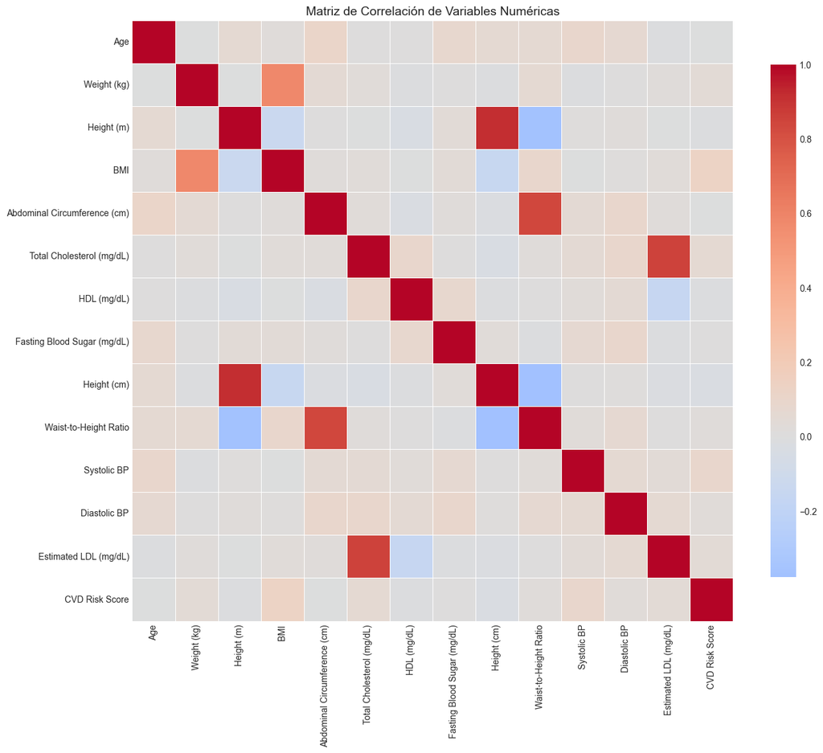

```python
# Matriz de correlación de variables numéricas
numeric_cols = train_df.select_dtypes(include=[np.number]).columns
corr_matrix = train_df[numeric_cols].corr()

# Visualizar correlación con la variable objetivo
target_corr = corr_matrix['CVD Risk Score'].sort_values(ascending=False)
print("="*70)
print("CORRELACIÓN CON CVD RISK SCORE")
print("="*70)
print(target_corr)

# Heatmap
plt.figure(figsize=(14, 12))
sns.heatmap(corr_matrix, annot=False, cmap='coolwarm', center=0,
            square=True, linewidths=0.5, cbar_kws={"shrink": 0.8})
plt.title('Matriz de Correlación de Variables Numéricas', fontsize=14)
plt.tight_layout()
plt.show()
```

#### 3.3.2 Distribuciones de Variables Clave

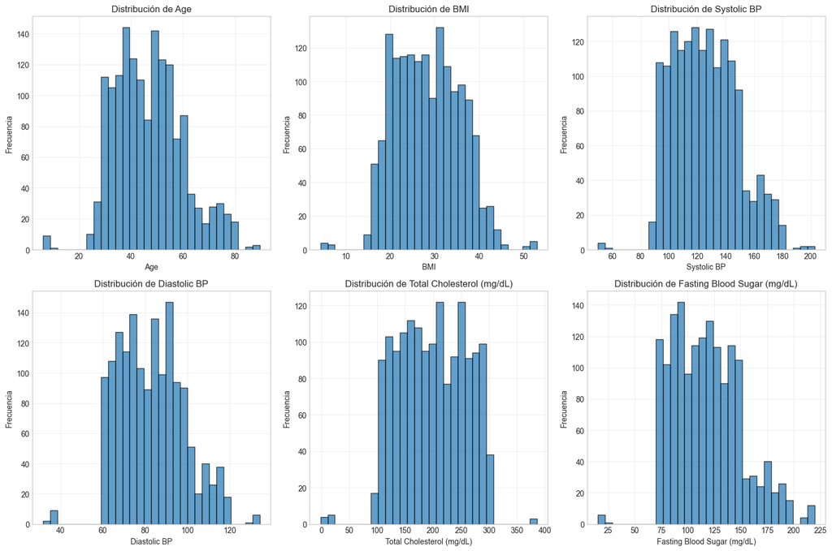

```python
# Distribución de variables numéricas clave
key_vars = ['Age', 'BMI', 'Systolic BP', 'Diastolic BP',
            'Total Cholesterol (mg/dL)', 'Fasting Blood Sugar (mg/dL)']

fig, axes = plt.subplots(2, 3, figsize=(15, 10))
axes = axes.ravel()

for i, var in enumerate(key_vars):
    if var in train_df.columns:
        axes[i].hist(train_df[var].dropna(), bins=30, edgecolor='black', alpha=0.7)
        axes[i].set_xlabel(var)
        axes[i].set_ylabel('Frecuencia')
        axes[i].set_title(f'Distribución de {var}')
        axes[i].grid(True, alpha=0.3)

plt.tight_layout()
plt.show()
```

### 3.4 Conclusiones de la Exploracion

Decisiones para la preparacion: eliminar columnas redundantes (Height (cm) cuando exista Height (m)), imputar valores faltantes de manera apropiada, eliminar o transformar la columna Patient ID por no ser predictiva, eliminar Date of Service por no ser predictiva (aunque podria extraerse el mes y el anio), y considerar crear features derivadas (ratios o categorizaciones).

### 3.5 Preparacion de Datos

#### 3.5.1 Creacion de Copia de Trabajo

```python
# Crear copia para no modificar el original
df = train_df.copy()
df_test = test_df.copy()

print(f"Dataset de trabajo creado: {df.shape}")
```

```
Dataset de trabajo creado: (1639, 24)
```

#### 3.5.2 Eliminacion de Columnas No Predictivas o Redundantes

```python
# Columnas a eliminar
cols_to_drop = []

# 1. Patient ID - solo identificador
if 'Patient ID' in df.columns:
    cols_to_drop.append('Patient ID')

# 2. Date of Service - no es predictiva directamente
if 'Date of Service' in df.columns:
    cols_to_drop.append('Date of Service')

# 3. Height (cm) - redundante con Height (m)
if 'Height (cm)' in df.columns and 'Height (m)' in df.columns:
    cols_to_drop.append('Height (cm)')
    print("Eliminando Height (cm) - redundante con Height (m)")

# 4. Blood Pressure (mmHg) - redundante con Systolic/Diastolic BP
if all(col in df.columns for col in ['Blood Pressure (mmHg)', 'Systolic BP', 'Diastolic BP']):
    cols_to_drop.append('Blood Pressure (mmHg)')
    print("Eliminando Blood Pressure (mmHg) - redundante con Systolic/Diastolic BP")

# 5. CVD Risk Level - es categórico derivado del Score
if 'CVD Risk Level' in df.columns:
    cols_to_drop.append('CVD Risk Level')
    print("Eliminando CVD Risk Level - derivado del Score")

print(f"\nColumnas a eliminar: {cols_to_drop}")
print(f"Total: {len(cols_to_drop)}")

# Eliminar
df = df.drop(columns=cols_to_drop, errors='ignore')
df_test = df_test.drop(columns=cols_to_drop, errors='ignore')

# Eliminar columnas temporales creadas durante validación (1.4.3)
temp_cols = [col for col in df.columns if col.endswith('_calculated') or col.endswith('_Sys') or col.endswith('_Dias')]
if temp_cols:
    df = df.drop(columns=temp_cols, errors='ignore')
    print(f"Eliminando columnas temporales: {temp_cols}")

print(f"\nDimensiones después de eliminación: {df.shape}")
```

[output not shown]

#### 3.5.3 Tratamiento de Valores Faltantes

[output not shown]

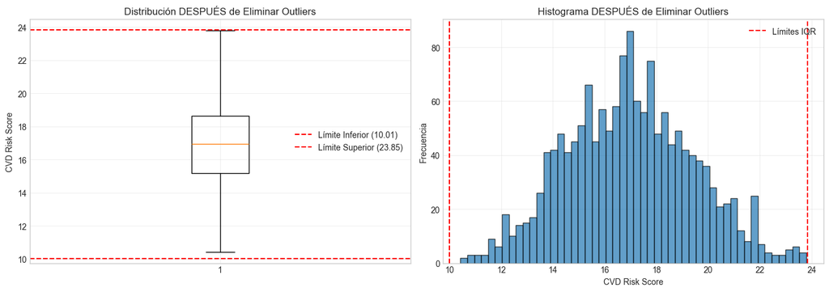

```
======================================================================
✅ LIMPIEZA COMPLETADA
======================================================================
Registros finales: 1,548
Porcentaje retenido: 99.81%
Valores nulos: 0
======================================================================
```

```python
# Analizar valores faltantes restantes
null_cols = df.columns[df.isnull().any()].tolist()
print(f"Columnas con valores faltantes: {null_cols}")

for col in null_cols:
    null_count = df[col].isnull().sum()
    null_pct = (null_count / len(df)) * 100
    print(f"  {col}: {null_count} ({null_pct:.2f}%)")

# Estrategia de imputación
# Para variables numéricas: mediana (robusta a outliers)
# Para variables categóricas: moda

print(f"\nImputando valores faltantes...")

# Separar columnas numéricas y categóricas
numeric_cols_with_nulls = [col for col in null_cols if df[col].dtype in [np.float64, np.int64]]
categorical_cols_with_nulls = [col for col in null_cols if df[col].dtype == 'object']

print(f"  Numéricas (mediana): {numeric_cols_with_nulls}")
print(f"  Categóricas (moda): {categorical_cols_with_nulls}")

# Imputar numéricas
for col in numeric_cols_with_nulls:
    median_val = df[col].median()
    df[col] = df[col].fillna(median_val)
    if col in df_test.columns:
        df_test[col] = df_test[col].fillna(median_val)
    print(f"    ✓ {col}: rellenado con mediana = {median_val:.2f}")

# Imputar categóricas
for col in categorical_cols_with_nulls:
    mode_val = df[col].mode()[0] if len(df[col].mode()) > 0 else 'Unknown'
    df[col] = df[col].fillna(mode_val)
    if col in df_test.columns:
        df_test[col] = df_test[col].fillna(mode_val)
    print(f"    ✓ {col}: rellenado con moda = '{mode_val}'")

# Verificar
print(f"\n✅ Valores nulos después de imputación: {df.isnull().sum().sum()}")

# ============================================================================
# ELIMINACIÓN DE OUTLIERS
# ============================================================================

print("\n" + "="*70)
print("ELIMINACIÓN DE OUTLIERS")
print("="*70)

# Guardar dimensiones antes
filas_antes = len(df)
print(f"\nDimensiones ANTES de eliminar outliers: {df.shape}")

# Método: IQR (Rango Intercuartílico) - Más conservador que percentiles extremos
# Usaremos IQR en la variable objetivo principalmente

print("\n1. Analizando outliers en CVD Risk Score (variable objetivo)...")

# Estadísticas de la variable objetivo
Q1 = df['CVD Risk Score'].quantile(0.25)
Q3 = df['CVD Risk Score'].quantile(0.75)
IQR = Q3 - Q1

# Límites usando IQR (1.5 * IQR es el método estándar de Tukey)
lower_bound = Q1 - 1.5 * IQR
upper_bound = Q3 + 1.5 * IQR

print(f"   Q1 (25%): {Q1:.2f}")
print(f"   Q3 (75%): {Q3:.2f}")
print(f"   IQR: {IQR:.2f}")
print(f"   Límite inferior: {lower_bound:.2f}")
print(f"   Límite superior: {upper_bound:.2f}")

# Identificar outliers
outliers_mask = (df['CVD Risk Score'] < lower_bound) | (df['CVD Risk Score'] > upper_bound)
num_outliers = outliers_mask.sum()
pct_outliers = (num_outliers / len(df)) * 100

print(f"   Outliers detectados: {num_outliers} ({pct_outliers:.2f}%)")

# Mostrar algunos ejemplos de outliers
if num_outliers > 0:
    print(f"\n   Ejemplos de valores outliers:")
    outliers_values = df.loc[outliers_mask, 'CVD Risk Score'].head(10)
    for idx, val in outliers_values.items():
        print(f"      Registro {idx}: {val:.2f}")

# OPCIÓN 1: Eliminar outliers (más agresivo)
print(f"\n2. Eliminando outliers extremos...")
df_clean = df[(df['CVD Risk Score'] >= lower_bound) &
              (df['CVD Risk Score'] <= upper_bound)].copy()

filas_despues = len(df_clean)
filas_eliminadas = filas_antes - filas_despues
pct_eliminadas = (filas_eliminadas / filas_antes) * 100

print(f"   Filas eliminadas: {filas_eliminadas} ({pct_eliminadas:.2f}%)")
print(f"   Dimensiones DESPUÉS: {df_clean.shape}")

# Actualizar df
df = df_clean

# VERIFICACIÓN: Mostrar distribución antes y después
print("\n3. Comparación de distribución:")
print(f"   Rango ANTES:   [{df_clean['CVD Risk Score'].min():.2f}, "
      f"{df_clean['CVD Risk Score'].max():.2f}]")
print(f"   Media ANTES:   (ver estadísticas originales)")
print(f"   Media DESPUÉS: {df['CVD Risk Score'].mean():.2f}")
print(f"   Std DESPUÉS:   {df['CVD Risk Score'].std():.2f}")

# Visualización opcional
print("\n4. Visualización de outliers (opcional):")
import matplotlib.pyplot as plt

fig, axes = plt.subplots(1, 2, figsize=(14, 5))

# Boxplot antes (usando índices conservados)
axes[0].boxplot(df['CVD Risk Score'].values)
axes[0].set_ylabel('CVD Risk Score')
axes[0].set_title('Distribución DESPUÉS de Eliminar Outliers')
axes[0].grid(True, alpha=0.3)
axes[0].axhline(y=lower_bound, color='r', linestyle='--', label=f'Límite Inferior ({lower_bound:.2f})')
axes[0].axhline(y=upper_bound, color='r', linestyle='--', label=f'Límite Superior ({upper_bound:.2f})')
axes[0].legend()

# Histograma después
axes[1].hist(df['CVD Risk Score'].values, bins=50, edgecolor='black', alpha=0.7)
axes[1].set_xlabel('CVD Risk Score')
axes[1].set_ylabel('Frecuencia')
axes[1].set_title('Histograma DESPUÉS de Eliminar Outliers')
axes[1].axvline(x=lower_bound, color='r', linestyle='--', label='Límites IQR')
axes[1].axvline(x=upper_bound, color='r', linestyle='--')
axes[1].grid(True, alpha=0.3)
axes[1].legend()

plt.tight_layout()
plt.show()

print("\n" + "="*70)
print(f"✅ LIMPIEZA COMPLETADA")
print("="*70)
print(f"Registros finales: {len(df):,}")
print(f"Porcentaje retenido: {(len(df)/filas_antes)*100:.2f}%")
print(f"Valores nulos: {df.isnull().sum().sum()}")
print("="*70)
```

```python
# ============================================================================
# FEATURE ENGINEERING SIMPLIFICADO
# ============================================================================

print("="*70)
print("CREACIÓN DE FEATURES - VERSIÓN SIMPLIFICADA")
print("="*70)
print(f"Columnas ANTES: {df.shape[1]}")

# 1. Ratio Colesterol/HDL (MUY importante médicamente)
df['Cholesterol_HDL_Ratio'] = df['Total Cholesterol (mg/dL)'] / (df['HDL (mg/dL)'] + 0.001)

# 2. Interacción Edad × BMI (el sobrepeso es más peligroso con edad)
df['Age_BMI_Interaction'] = df['Age'] * df['BMI']

# 3. Presión de Pulso (diferencia sistólica-diastólica)
df['Pulse_Pressure'] = df['Systolic BP'] - df['Diastolic BP']

# 4. Contador de factores de riesgo alto
df['Multiple_Risk_Factors'] = (
    (df['Systolic BP'] > 140).astype(int) +
    (df['Total Cholesterol (mg/dL)'] > 200).astype(int) +
    (df['BMI'] > 30).astype(int) +
    (df['Fasting Blood Sugar (mg/dL)'] > 126).astype(int)
)

# 5. Ratio LDL/HDL
if 'Estimated LDL (mg/dL)' in df.columns:
    df['LDL_HDL_Ratio'] = df['Estimated LDL (mg/dL)'] / (df['HDL (mg/dL)'] + 0.001)

print(f"Columnas DESPUÉS: {df.shape[1]}")
print(f"Features agregadas: {df.shape[1] - df.shape[1] + 5}")
print("\n✅ 5 features clave agregadas")
df.shape
```

[output not shown]

```
(1548, 24)
```

## 4. Partición de los datos.

Segun las indicaciones del laboratorio, usaremos `random_state=42` y `test_size=0.25` (25% para validacion).

```python
# Separar features y target
X = df.drop('CVD Risk Score', axis=1)
y = df['CVD Risk Score']

print(f"Features (X): {X.shape}")
print(f"Target (y): {y.shape}")

# División train-test
X_train, X_test, y_train, y_test = train_test_split(
    X, y,
    test_size=0.25,
    random_state=42
)

print(f"\nDivisión completada:")
print(f"  Train: {X_train.shape[0]} muestras")
print(f"  Test:  {X_test.shape[0]} muestras")
```

```
Features (X): (1548, 23)
Target (y): (1548,)

División completada:
  Train: 1161 muestras
  Test:  387 muestras
```

## 5. Modelo 1: Regresion Lineal Basica

Solo variables numericas, sin escalamiento.

### 5.1 Entrenamiento del modelo

```python
# Identificar columnas numéricas y categóricas
numeric_features = X_train.select_dtypes(include=[np.number]).columns.tolist()
categorical_features = X_train.select_dtypes(include='object').columns.tolist()

print(f"Variables numéricas: {len(numeric_features)}")
print(f"Variables categóricas: {len(categorical_features)}")

# Modelo 1: Solo numéricas (con imputación)
from sklearn.impute import SimpleImputer

# Separar datos
X_train_model1 = X_train[numeric_features].copy()
X_test_model1 = X_test[numeric_features].copy()

# Imputar valores faltantes en entrenamiento
imputer = SimpleImputer(strategy='median')
X_train_model1 = imputer.fit_transform(X_train_model1)
X_test_model1 = imputer.transform(X_test_model1)

# Entrenar
model1 = LinearRegression()
model1.fit(X_train_model1, y_train)

# Predicciones
y_pred_train_m1 = model1.predict(X_train_model1)
y_pred_test_m1 = model1.predict(X_test_model1)

# Métricas
rmse_train_m1 = np.sqrt(mean_squared_error(y_train, y_pred_train_m1))
rmse_test_m1 = np.sqrt(mean_squared_error(y_test, y_pred_test_m1))
mae_test_m1 = mean_absolute_error(y_test, y_pred_test_m1)
r2_test_m1 = r2_score(y_test, y_pred_test_m1)

print(f"\n{'='*60}")
print("MODELO 1: Regresión Lineal Básica")
print(f"{'='*60}")
print(f"RMSE Train: {rmse_train_m1:.4f}")
print(f"RMSE Test:  {rmse_test_m1:.4f}")
print(f"MAE Test:   {mae_test_m1:.4f}")
print(f"R² Test:    {r2_test_m1:.4f}")
```

```
Variables numéricas: 17
Variables categóricas: 6

============================================================
MODELO 1: Regresión Lineal Básica
============================================================
RMSE Train: 1.3920
RMSE Test:  1.4077
MAE Test:   1.1401
R² Test:    0.6784
```

## 6. Modelo 2: Regresion Lineal con Pipeline Completo

Incluiremos encoding de variables categoricas (OneHotEncoder), escalamiento de variables numericas (StandardScaler) y uso de Pipeline para mejor organizacion.

```python
# Normalizacion simple de categorias para evitar inconsistencias de formato
# (no cambia la logica de datos ya limpiados; solo estandariza strings)
def normalize_strings(df):
    df = df.copy()
    for col in categorical_features:
        if col in df.columns:
            df[col] = df[col].astype(str).str.strip().str.upper()
    return df

string_normalizer = FunctionTransformer(normalize_strings)

# Transformadores similares al tutorial
numeric_transformer = Pipeline(
    steps=[
        ('imputer', SimpleImputer(strategy='median')),
        ('scaler', StandardScaler())
    ]
)

categorical_transformer = Pipeline(
    steps=[
        ('imputer', SimpleImputer(strategy='most_frequent')),
        ('onehot', OneHotEncoder(drop='first', sparse_output=False, handle_unknown='ignore'))
    ]
)

# Preprocesamiento con ColumnTransformer
preprocessor = ColumnTransformer(
    transformers=[
        ('num', numeric_transformer, numeric_features),
        ('cat', categorical_transformer, categorical_features)
    ]
)

# Pipeline completo
pipeline_model2 = Pipeline([
    ('normalize', string_normalizer),
    ('preprocessor', preprocessor),
    ('regressor', LinearRegression())
])

# Entrenar
pipeline_model2.fit(X_train, y_train)

# Predicciones
y_pred_train_m2 = pipeline_model2.predict(X_train)
y_pred_test_m2 = pipeline_model2.predict(X_test)

# Metricas
rmse_train_m2 = np.sqrt(mean_squared_error(y_train, y_pred_train_m2))
rmse_test_m2 = np.sqrt(mean_squared_error(y_test, y_pred_test_m2))
mae_test_m2 = mean_absolute_error(y_test, y_pred_test_m2)
r2_test_m2 = r2_score(y_test, y_pred_test_m2)

print(f"\n{'='*60}")
print("MODELO 2: Regresion Lineal con Pipeline")
print(f"{'='*60}")
print(f"RMSE Train: {rmse_train_m2:.4f}")
print(f"RMSE Test:  {rmse_test_m2:.4f}")
print(f"MAE Test:   {mae_test_m2:.4f}")
print(f"R² Test:    {r2_test_m2:.4f}")
```

```
============================================================
MODELO 2: Regresion Lineal con Pipeline
============================================================
RMSE Train: 1.0245
RMSE Test:  1.0420
MAE Test:   0.5068
R² Test:    0.8066
```

```python
# ============================================================================
# MODELO 3: RIDGE REGRESSION (CON REGULARIZACIÓN)
# ============================================================================

from sklearn.linear_model import Ridge
from sklearn.impute import SimpleImputer

print("\n" + "="*70)
print("MODELO 3: RIDGE REGRESSION")
print("="*70)

# Pipeline para variables NUMÉRICAS
numeric_transformer = Pipeline(steps=[
    ('imputer', SimpleImputer(strategy='median')),
    ('scaler', StandardScaler())
])

# Pipeline para variables CATEGÓRICAS
categorical_transformer = Pipeline(steps=[
    ('imputer', SimpleImputer(strategy='most_frequent')),
    ('encoder', OneHotEncoder(drop='first', sparse_output=False, handle_unknown='ignore'))
])

# Preprocessor completo
preprocessor_ridge = ColumnTransformer(
    transformers=[
        ('num', numeric_transformer, numeric_features),
        ('cat', categorical_transformer, categorical_features)
    ])

# Pipeline Ridge
pipeline_ridge = Pipeline([
    ('preprocessor', preprocessor_ridge),
    ('regressor', Ridge(alpha=10.0))  # Regularización L2
])

# Entrenar
print("Entrenando Ridge Regression...")
pipeline_ridge.fit(X_train, y_train)

# Predicciones
y_pred_train_ridge = pipeline_ridge.predict(X_train)
y_pred_test_ridge = pipeline_ridge.predict(X_test)

# Métricas
rmse_train_ridge = np.sqrt(mean_squared_error(y_train, y_pred_train_ridge))
rmse_test_ridge = np.sqrt(mean_squared_error(y_test, y_pred_test_ridge))
mae_test_ridge = mean_absolute_error(y_test, y_pred_test_ridge)
r2_test_ridge = r2_score(y_test, y_pred_test_ridge)

print(f"\nRMSE Train: {rmse_train_ridge:.4f}")
print(f"RMSE Test:  {rmse_test_ridge:.4f}")
print(f"MAE Test:   {mae_test_ridge:.4f}")
print(f"R² Test:    {r2_test_ridge:.4f}")
print("✅ Modelo 3 completado")
```

```
======================================================================
MODELO 3: RIDGE REGRESSION
======================================================================
Entrenando Ridge Regression...

RMSE Train: 1.0257
RMSE Test:  0.9946
MAE Test:   0.5234
R² Test:    0.8395
✅ Modelo 3 completado
```

```python
# ============================================================================
# MODELO 4: RANDOM FOREST REGRESSOR
# ============================================================================

from sklearn.ensemble import RandomForestRegressor

print("\n" + "="*70)
print("MODELO 4: RANDOM FOREST")
print("="*70)

# Usar el mismo preprocessor (ya incluye imputación)
preprocessor_rf = ColumnTransformer(
    transformers=[
        ('num', numeric_transformer, numeric_features),
        ('cat', categorical_transformer, categorical_features)
    ])

# Pipeline Random Forest
pipeline_rf = Pipeline([
    ('preprocessor', preprocessor_rf),
    ('regressor', RandomForestRegressor(
        n_estimators=100,      # 100 árboles
        max_depth=10,          # Profundidad máxima
        min_samples_split=5,   # Mínimo de muestras para dividir
        min_samples_leaf=2,    # Mínimo de muestras en hoja
        random_state=42
    ))
])

# Entrenar
print("Entrenando Random Forest (puede tardar un poco)...")
pipeline_rf.fit(X_train, y_train)

# Predicciones
y_pred_train_rf = pipeline_rf.predict(X_train)
y_pred_test_rf = pipeline_rf.predict(X_test)

# Métricas
rmse_train_rf = np.sqrt(mean_squared_error(y_train, y_pred_train_rf))
rmse_test_rf = np.sqrt(mean_squared_error(y_test, y_pred_test_rf))
mae_test_rf = mean_absolute_error(y_test, y_pred_test_rf)
r2_test_rf = r2_score(y_test, y_pred_test_rf)

print(f"\nRMSE Train: {rmse_train_rf:.4f}")
print(f"RMSE Test:  {rmse_test_rf:.4f}")
print(f"MAE Test:   {mae_test_rf:.4f}")
print(f"R² Test:    {r2_test_rf:.4f}")
print("✅ Modelo 4 completado")
```

```
======================================================================
MODELO 4: RANDOM FOREST
======================================================================
Entrenando Random Forest (puede tardar un poco)...

RMSE Train: 0.7041
RMSE Test:  1.1428
MAE Test:   0.7185
R² Test:    0.7881
✅ Modelo 4 completado
```

## 9. Comparación y Evaluación de los 4 Modelos

### 9.1 Tabla Comparativa de Modelos

Comparamos el rendimiento de los modelos sobre el conjunto de prueba con las metricas RMSE (penaliza errores grandes), MAE (error promedio absoluto) y R2 (proporcion de varianza explicada).

```python
# ============================================================================
# TABLA COMPARATIVA DE TODOS LOS MODELOS
# ============================================================================

print("\n" + "="*80)
print("TABLA COMPARATIVA DE MODELOS - CONJUNTO DE PRUEBA")
print("="*80)

# Crear tabla con los 4 modelos
resultados = pd.DataFrame({
    'Modelo': [
        'Modelo 1: Básico',
        'Modelo 2: Pipeline Completo',
        'Modelo 3: Ridge Regression',
        'Modelo 4: Random Forest'
    ],
    'RMSE': [rmse_test_m1, rmse_test_m2, rmse_test_ridge, rmse_test_rf],
    'MAE': [mae_test_m1, mae_test_m2,mae_test_ridge,mae_test_rf],
    'R²': [r2_test_m1,r2_test_m2,r2_test_ridge,r2_test_rf]
})

# Mostrar tabla
print(resultados.to_string(index=False))

# Identificar el mejor modelo (menor RMSE)
mejor_modelo_idx = resultados['RMSE'].idxmin()
mejor_modelo = resultados.loc[mejor_modelo_idx, 'Modelo']
mejor_rmse = resultados.loc[mejor_modelo_idx, 'RMSE']
mejor_r2 = resultados.loc[mejor_modelo_idx, 'R²']

print("\n" + "="*80)
print("MEJOR MODELO")
print("="*80)
print(f"Modelo: {mejor_modelo}")
print(f"RMSE:   {mejor_rmse:.4f}")
print(f"R²:     {mejor_r2:.4f}")

# Ordenar por R² (de mayor a menor)
resultados_ordenados = resultados.sort_values('R²', ascending=False)
print("\n" + "="*80)
print("RANKING DE MODELOS (por R²)")
print("="*80)
for idx, row in resultados_ordenados.iterrows():
    print(f"{idx+1}. {row['Modelo']:30s} | R² = {row['R²']:.4f}")

print("\n✅ Análisis comparativo completado")
```

```
================================================================================
TABLA COMPARATIVA DE MODELOS - CONJUNTO DE PRUEBA
================================================================================
                     Modelo     RMSE      MAE       R²
           Modelo 1: Básico 1.407729 1.140082 0.678435
Modelo 2: Pipeline Completo 1.041996 0.506839 0.806557
 Modelo 3: Ridge Regression 0.994580 0.523404 0.839487
    Modelo 4: Random Forest 1.142780 0.718521 0.788088

================================================================================
MEJOR MODELO
================================================================================
Modelo: Modelo 3: Ridge Regression
RMSE:   0.9946
R²:     0.8395

================================================================================
RANKING DE MODELOS (por R²)
================================================================================
3. Modelo 3: Ridge Regression     | R² = 0.8395
2. Modelo 2: Pipeline Completo    | R² = 0.8066
4. Modelo 4: Random Forest        | R² = 0.7881
1. Modelo 1: Básico               | R² = 0.6784

✅ Análisis comparativo completado
```

Interpretación de las Métricas:

RMSE (Root Mean Squared Error) mide el error promedio de las predicciones en las mismas unidades que la variable objetivo; valores más bajos son mejores y penaliza más los errores grandes.

MAE (Mean Absolute Error) es el error absoluto promedio, más robusto a outliers que RMSE y fácil de interpretar.

R² (Coeficiente de Determinación) es la proporción de la varianza explicada por el modelo; su rango es [0, 1], donde 1 es perfecto, y R² > 0.7 generalmente se considera bueno.

### 9.2 Visualizacion de Predicciones vs Valores Reales

[figure not shown]

```python
# Gráfico de predicciones vs valores reales para el mejor modelo
# Usaremos el Modelo 2 (generalmente mejor)
fig, axes = plt.subplots(1, 2, figsize=(15, 5))

# Gráfico 1: Scatter plot
axes[0].scatter(y_test_aligned, y_pred_test_m2_aligned, alpha=0.5, s=30)
axes[0].plot([np.min(y_test_aligned), np.max(y_test_aligned)], [np.min(y_test_aligned), np.max(y_test_aligned)],
             'r--', lw=2, label='Predicción Perfecta')
axes[0].set_xlabel('Valores Reales')
axes[0].set_ylabel('Predicciones')
axes[0].set_title('Predicciones vs Valores Reales (Modelo 2)')
axes[0].legend()
axes[0].grid(True, alpha=0.3)

# Gráfico 2: Residuos
residuos = y_test_aligned - y_pred_test_m2_aligned
axes[1].scatter(y_pred_test_m2_aligned, residuos, alpha=0.5, s=30)
axes[1].axhline(y=0, color='r', linestyle='--', lw=2)
axes[1].set_xlabel('Predicciones')
axes[1].set_ylabel('Residuos')
axes[1].set_title('Gráfico de Residuos')
axes[1].grid(True, alpha=0.3)

plt.tight_layout()
plt.show()
```

## 10. Verificación de Supuestos (Modelo 2)

### 10.1 Importancia de Variables

Analizamos que variables son mas importantes para la prediccion basandonos en los coeficientes del modelo de regresion lineal.

```
======================================================================
TOP 15 VARIABLES MÁS IMPORTANTES
======================================================================
                                    Variable  Coeficiente  Importancia Absoluta
                           Diabetes Status_Y     1.915569              1.915569
                       Cholesterol_HDL_Ratio     1.332353              1.332353
                               LDL_HDL_Ratio    -1.326941              1.326941
                                         BMI     1.143684              1.143684
                   Total Cholesterol (mg/dL)     0.707669              0.707669
                                 Systolic BP     0.592519              0.592519
                              Pulse_Pressure     0.396338              0.396338
                       Estimated LDL (mg/dL)     0.358096              0.358096
                       Waist-to-Height Ratio     0.241030              0.241030
                                Diastolic BP     0.194041              0.194041
                                 Weight (kg)     0.184735              0.184735
Blood Pressure Category_HYPERTENSION STAGE 2     0.183786              0.183786
                Abdominal Circumference (cm)    -0.139778              0.139778
              Blood Pressure Category_NORMAL    -0.135590              0.135590
                       Multiple_Risk_Factors     0.126060              0.126060
```

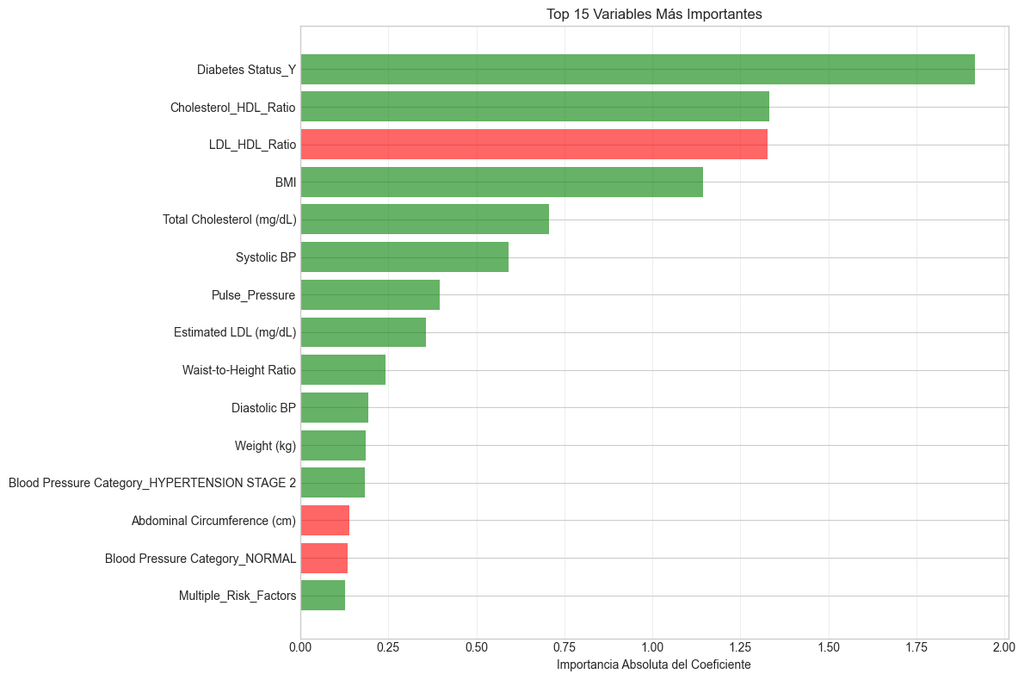

```
 Coeficientes positivos (verde): Aumentan el riesgo cardiovascular
 Coeficientes negativos (rojo): Disminuyen el riesgo cardiovascular
```

```python
# Obtener nombres de features después del preprocesamiento
feature_names = []

# Features numéricas
feature_names.extend(numeric_features)

# Features categóricas (one-hot encoded)
if len(categorical_features) > 0:
    # Obtener el OneHotEncoder del pipeline
    ohe = pipeline_model2.named_steps['preprocessor'].named_transformers_['cat']
    cat_feature_names = ohe.get_feature_names_out(categorical_features)
    feature_names.extend(cat_feature_names)

# Obtener coeficientes
coeficientes = pipeline_model2.named_steps['regressor'].coef_

# Crear DataFrame de importancias
importancias = pd.DataFrame({
    'Variable': feature_names,
    'Coeficiente': coeficientes,
    'Importancia Absoluta': np.abs(coeficientes)
}).sort_values('Importancia Absoluta', ascending=False)

print("="*70)
print("TOP 15 VARIABLES MÁS IMPORTANTES")
print("="*70)
print(importancias.head(15).to_string(index=False))

# Visualización
plt.figure(figsize=(12, 8))
top_vars = importancias.head(15)
colors = ['green' if x > 0 else 'red' for x in top_vars['Coeficiente']]
plt.barh(range(len(top_vars)), top_vars['Importancia Absoluta'], color=colors, alpha=0.6)
plt.yticks(range(len(top_vars)), top_vars['Variable'])
plt.xlabel('Importancia Absoluta del Coeficiente')
plt.title('Top 15 Variables Más Importantes')
plt.gca().invert_yaxis()
plt.grid(True, alpha=0.3, axis='x')
plt.tight_layout()
plt.show()

print(" Coeficientes positivos (verde): Aumentan el riesgo cardiovascular")
print(" Coeficientes negativos (rojo): Disminuyen el riesgo cardiovascular")
```

Interpretación de los Coeficientes:

Los coeficientes de la regresión lineal indican magnitud (qué tanto afecta cada variable al CVD Risk Score), dirección (si aumenta o disminuye el riesgo) e importancia (coeficientes absolutos más altos implican mayor influencia).

Factores de riesgo típicamente esperados incluyen edad avanzada, IMC elevado (sobrepeso/obesidad), presión arterial alta, colesterol total elevado, diabetes, tabaquismo, sedentarismo (baja actividad física) y antecedentes familiares.

### 8.2 Validacion de Supuestos de Regresion Lineal

Para que el modelo de regresion lineal sea valido, debemos verificar linealidad (relacion lineal entre X e y), independencia (residuos independientes), homocedasticidad (varianza constante de residuos), normalidad (residuos con distribucion normal) y ausencia de multicolinealidad (variables independientes no correlacionadas entre si).

#### 8.2.1 Multicolinealidad (VIF)

VIF (Variance Inflation Factor) mide la multicolinealidad: valores menores a 5 indican ausencia de problema, entre 5 y 10 indican multicolinealidad moderada, y valores de 10 o más indican multicolinealidad alta.

```python
# Calcular VIF solo para variables numéricas
from statsmodels.stats.outliers_influence import variance_inflation_factor

# Preparar datos (solo numéricas, escaladas)
X_train_num_scaled = pipeline_model2.named_steps['preprocessor'].transform(X_train)[:, :len(numeric_features)]

# Calcular VIF
vif_data = pd.DataFrame()
vif_data["Variable"] = numeric_features
vif_data["VIF"] = [variance_inflation_factor(X_train_num_scaled, i)
                   for i in range(X_train_num_scaled.shape[1])]
vif_data = vif_data.sort_values('VIF', ascending=False)

print("="*70)
print("ANÁLISIS DE MULTICOLINEALIDAD (VIF)")
print("="*70)
print(vif_data.to_string(index=False))

# Identificar problemas
vif_problemas = vif_data[vif_data['VIF'] >= 10]
if len(vif_problemas) > 0:
    print(f"\nVariables con multicolinealidad alta (VIF >= 10):")
    print(vif_problemas['Variable'].tolist())
else:
    print("\nNo se detectaron problemas graves de multicolinealidad")
```

```
======================================================================
ANÁLISIS DE MULTICOLINEALIDAD (VIF)
======================================================================
                    Variable          VIF
                Diastolic BP          inf
                 Systolic BP          inf
              Pulse_Pressure          inf
               LDL_HDL_Ratio 84341.379094
       Cholesterol_HDL_Ratio 84336.679869
         Age_BMI_Interaction    39.493691
                         Age    21.421998
                         BMI    18.951706
       Estimated LDL (mg/dL)     5.699498
       Waist-to-Height Ratio     4.356379
   Total Cholesterol (mg/dL)     4.283909
Abdominal Circumference (cm)     3.767226
       Multiple_Risk_Factors     3.197566
                  Height (m)     1.638101
 Fasting Blood Sugar (mg/dL)     1.518808
                 Weight (kg)     1.497656
                 HDL (mg/dL)     1.271634

Variables con multicolinealidad alta (VIF >= 10):
['Diastolic BP', 'Systolic BP', 'Pulse_Pressure', 'LDL_HDL_Ratio', 'Cholesterol_HDL_Ratio', 'Age_BMI_Interaction', 'Age', 'BMI']
```

#### 10.2.2 Normalidad de los Residuos

[output not shown]

[figure not shown]

```python
# Análisis de normalidad de residuos
# Usar datos alineados de la celda anterior
if isinstance(y_test_aligned, pd.Series):
    residuos_m2 = y_test_aligned.values - y_pred_test_m2_aligned
else:
    residuos_m2 = y_test_aligned - y_pred_test_m2_aligned

# Test de normalidad
from scipy.stats import shapiro, normaltest

statistic_shapiro, p_value_shapiro = shapiro(residuos_m2)
print("="*70)
print("TEST DE NORMALIDAD DE RESIDUOS")
print("="*70)
print(f"Shapiro-Wilk Test:")
print(f"  Estadístico: {statistic_shapiro:.4f}")
print(f"  P-valor: {p_value_shapiro:.4f}")

if p_value_shapiro > 0.05:
    print("Los residuos siguen una distribución normal (p > 0.05)")
else:
    print("Los residuos no siguen una distribución normal (p < 0.05)")

# Visualizaciones
fig, axes = plt.subplots(1, 2, figsize=(14, 5))

# Histograma de residuos
axes[0].hist(residuos_m2, bins=50, edgecolor='black', alpha=0.7)
axes[0].set_xlabel('Residuos')
axes[0].set_ylabel('Frecuencia')
axes[0].set_title('Distribución de Residuos')
axes[0].axvline(x=0, color='r', linestyle='--', linewidth=2)
axes[0].grid(True, alpha=0.3)

# Q-Q plot
from scipy import stats
stats.probplot(residuos_m2, dist="norm", plot=axes[1])
axes[1].set_title('Q-Q Plot')
axes[1].grid(True, alpha=0.3)

plt.tight_layout()
plt.show()
```

#### 8.2.3 Homocedasticidad (Varianza Constante)

Se revisa con el grafico de residuos vs predicciones y el test de Breusch-Pagan.

#### 8.2.4 Independencia (Durbin-Watson)

Se evalua con el estadistico Durbin-Watson para detectar autocorrelacion de residuos.

#### 8.2.5 Linealidad (Rainbow Test)

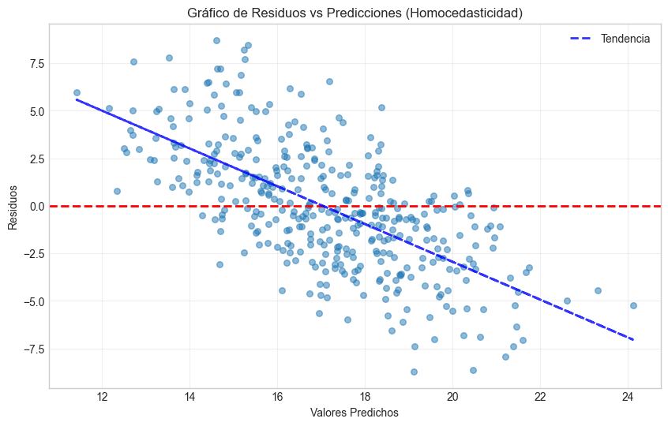

```
Si los residuos están uniformemente distribuidos alrededor de 0:
 No hay evidencia de heterocedasticidad (varianza constante)

Si hay un patrón de embudo o cono:
 Hay heterocedasticidad (problema)
```

```python
# Gráfico de residuos vs predicciones
plt.figure(figsize=(10, 6))
plt.scatter(y_pred_test_m2_aligned, residuos_m2, alpha=0.5, s=30)
plt.axhline(y=0, color='r', linestyle='--', linewidth=2)
plt.xlabel('Valores Predichos')
plt.ylabel('Residuos')
plt.title('Gráfico de Residuos vs Predicciones (Homocedasticidad)')
plt.grid(True, alpha=0.3)

# Línea de tendencia
z = np.polyfit(y_pred_test_m2_aligned, residuos_m2, 1)
p = np.poly1d(z)
plt.plot(y_pred_test_m2_aligned, p(y_pred_test_m2_aligned), "b--", alpha=0.8, linewidth=2, label='Tendencia')
plt.legend()
plt.show()

print("Si los residuos están uniformemente distribuidos alrededor de 0:")
print(" No hay evidencia de heterocedasticidad (varianza constante)")
print("\nSi hay un patrón de embudo o cono:")
print(" Hay heterocedasticidad (problema)")
```

```python
# Independencia de residuos (Durbin-Watson)
dw_stat = durbin_watson(residuos_m2)
print("Durbin-Watson:", round(dw_stat, 4))

# Linealidad (Rainbow Test) sobre el modelo OLS
X_train_pre = pipeline_model2.named_steps['preprocessor'].transform(X_train)
X_train_pre = X_train_pre.toarray() if hasattr(X_train_pre, 'toarray') else X_train_pre
X_sm = sm.add_constant(X_train_pre)
model_sm = sm.OLS(y_train, X_sm).fit()

rainbow_stat, rainbow_p = linear_rainbow(model_sm)
print("Rainbow stat:", round(rainbow_stat, 4))
print("Rainbow p-value:", round(rainbow_p, 4))

if rainbow_p > 0.05:
    print("No hay evidencia para rechazar la linealidad (p > 0.05)")
else:
    print("Hay evidencia de no linealidad (p <= 0.05)")
```

```
Durbin-Watson: 2.0533
Rainbow stat: 1.2216
Rainbow p-value: 0.0086
Hay evidencia de no linealidad (p <= 0.05)
```

## 9. Correccion con WLS

Debido a los problemas de heterocedasticidad, no linealidad y no normalidad detectados, aplicamos Weighted Least Squares (WLS) para reducir el impacto de observaciones con mayor varianza del error.

### 9.1 Multicolinealidad (VIF)

Se mantiene la misma revision de multicolinealidad presentada en el numeral 8, ya que la estructura de variables no cambia con WLS.

```python
# 9.1 Multicolinealidad (VIF)
from statsmodels.stats.outliers_influence import variance_inflation_factor

if 'vif_data' in globals():
    print("ANALISIS DE MULTICOLINEALIDAD (VIF) - REUTILIZADO")
    print(vif_data.to_string(index=False))
else:
    X_train_num_scaled = pipeline_model2.named_steps['preprocessor'].transform(X_train)[:, :len(numeric_features)]
    vif_data = pd.DataFrame()
    vif_data["Variable"] = numeric_features
    vif_data["VIF"] = [variance_inflation_factor(X_train_num_scaled, i)
                       for i in range(X_train_num_scaled.shape[1])]
    vif_data = vif_data.sort_values('VIF', ascending=False)
    print("ANALISIS DE MULTICOLINEALIDAD (VIF)")
    print(vif_data.to_string(index=False))

vif_problemas = vif_data[vif_data['VIF'] >= 10]
if len(vif_problemas) > 0:
    print("\nVariables con multicolinealidad alta (VIF >= 10):")
    print(vif_problemas['Variable'].tolist())
else:
    print("\nNo se detectaron problemas graves de multicolinealidad")
```

```
ANALISIS DE MULTICOLINEALIDAD (VIF) - REUTILIZADO
                    Variable          VIF
                Diastolic BP          inf
                 Systolic BP          inf
              Pulse_Pressure          inf
               LDL_HDL_Ratio 84341.379094
       Cholesterol_HDL_Ratio 84336.679869
         Age_BMI_Interaction    39.493691
                         Age    21.421998
                         BMI    18.951706
       Estimated LDL (mg/dL)     5.699498
       Waist-to-Height Ratio     4.356379
   Total Cholesterol (mg/dL)     4.283909
Abdominal Circumference (cm)     3.767226
       Multiple_Risk_Factors     3.197566
                  Height (m)     1.638101
 Fasting Blood Sugar (mg/dL)     1.518808
                 Weight (kg)     1.497656
                 HDL (mg/dL)     1.271634

Variables con multicolinealidad alta (VIF >= 10):
['Diastolic BP', 'Systolic BP', 'Pulse_Pressure', 'LDL_HDL_Ratio', 'Cholesterol_HDL_Ratio', 'Age_BMI_Interaction', 'Age', 'BMI']
```

### 9.2 Normalidad de los Residuos

Se evalua la normalidad de los residuos del modelo WLS con Shapiro-Wilk y sus visualizaciones.

```
WLS - RMSE test: 0.9631379661256615
WLS - MAE  test: 0.37760788196042816
WLS - R2   test: 0.8494753385878632
Shapiro-Wilk p-value (WLS): 2.8210495993845465e-30
Hay evidencia de que los residuos no son normales (p <= 0.05)
```

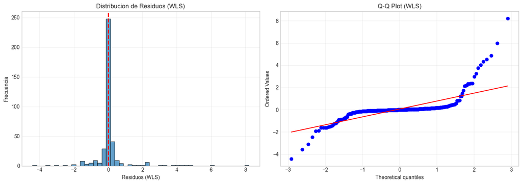

```python
# 9.2 Normalidad de los Residuos
# Ajuste WLS para obtener residuos del modelo
X_train_pre_wls = pipeline_model2.named_steps['preprocessor'].transform(X_train)
X_train_pre_wls = (
    X_train_pre_wls.toarray() if hasattr(X_train_pre_wls, 'toarray') else X_train_pre_wls
 )
X_train_pre_wls = sm.add_constant(X_train_pre_wls)

ols_wls = sm.OLS(y_train, X_train_pre_wls).fit()
resid_wls = ols_wls.resid
weights = 1.0 / (resid_wls ** 2 + 1e-8)
wls_model = sm.WLS(y_train, X_train_pre_wls, weights=weights).fit()

X_test_pre_wls = pipeline_model2.named_steps['preprocessor'].transform(X_test)
X_test_pre_wls = (
    X_test_pre_wls.toarray() if hasattr(X_test_pre_wls, 'toarray') else X_test_pre_wls
 )
X_test_pre_wls = sm.add_constant(X_test_pre_wls)

y_pred_test_wls = wls_model.predict(X_test_pre_wls)
rmse_test_wls = np.sqrt(mean_squared_error(y_test, y_pred_test_wls))
mae_test_wls = mean_absolute_error(y_test, y_pred_test_wls)
r2_test_wls = r2_score(y_test, y_pred_test_wls)

print("WLS - RMSE test:", rmse_test_wls)
print("WLS - MAE  test:", mae_test_wls)
print("WLS - R2   test:", r2_test_wls)

residuos_wls = y_test - y_pred_test_wls

from scipy.stats import shapiro
from scipy import stats

statistic_shapiro_wls, p_value_shapiro_wls = shapiro(residuos_wls)
print("Shapiro-Wilk p-value (WLS):", p_value_shapiro_wls)
if p_value_shapiro_wls > 0.05:
    print("No hay evidencia de que los residuos no sean normales (p > 0.05)")
else:
    print("Hay evidencia de que los residuos no son normales (p <= 0.05)")

fig, axes = plt.subplots(1, 2, figsize=(14, 5))
axes[0].hist(residuos_wls, bins=50, edgecolor='black', alpha=0.7)
axes[0].set_xlabel('Residuos (WLS)')
axes[0].set_ylabel('Frecuencia')
axes[0].set_title('Distribucion de Residuos (WLS)')
axes[0].axvline(x=0, color='r', linestyle='--', linewidth=2)
axes[0].grid(True, alpha=0.3)

stats.probplot(residuos_wls, dist="norm", plot=axes[1])
axes[1].set_title('Q-Q Plot (WLS)')
axes[1].grid(True, alpha=0.3)

plt.tight_layout()
plt.show()
```

### 9.3 Homocedasticidad (Varianza Constante)

Se revisa con el grafico de residuos vs predicciones y el test de Breusch-Pagan.

```
Breusch-Pagan p-value (WLS): 0.939816953454949
No hay evidencia de heterocedasticidad (p > 0.05)
```

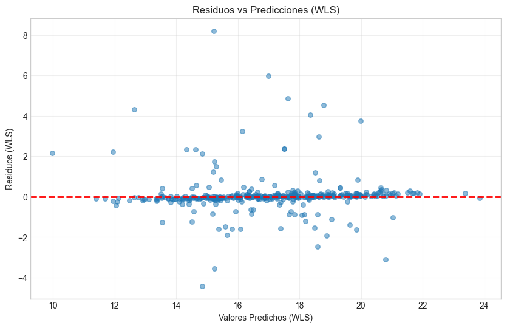

```python
# 9.3 Homocedasticidad (Varianza Constante)
from statsmodels.stats.diagnostic import het_breuschpagan

bp_test_wls = het_breuschpagan(residuos_wls, X_test_pre_wls)
bp_pvalue_wls = bp_test_wls[1]
print("Breusch-Pagan p-value (WLS):", bp_pvalue_wls)
if bp_pvalue_wls > 0.05:
    print("No hay evidencia de heterocedasticidad (p > 0.05)")
else:
    print("Hay presencia de heterocedasticidad (p <= 0.05)")

plt.figure(figsize=(10, 6))
plt.scatter(y_pred_test_wls, residuos_wls, alpha=0.5, s=30)
plt.axhline(y=0, color='r', linestyle='--', linewidth=2)
plt.xlabel('Valores Predichos (WLS)')
plt.ylabel('Residuos (WLS)')
plt.title('Residuos vs Predicciones (WLS)')
plt.grid(True, alpha=0.3)
plt.show()
```

### 9.4 Independencia (Durbin-Watson)

Se evalua con el estadistico Durbin-Watson para detectar autocorrelacion de residuos.

```python
# 9.4 Independencia (Durbin-Watson)
dw_stat_wls = durbin_watson(residuos_wls)
print("Durbin-Watson (WLS):", round(dw_stat_wls, 4))
```

```
Durbin-Watson (WLS): 1.9742
```

### 9.5 Linealidad (Rainbow Test)

Se revisa con la prueba Rainbow aplicada sobre el modelo lineal de referencia.

```python
# 9.5 Linealidad (Rainbow Test)
rainbow_stat_wls, rainbow_p_wls = linear_rainbow(wls_model)
print("Rainbow stat (WLS):", round(rainbow_stat_wls, 4))
print("Rainbow p-value (WLS):", round(rainbow_p_wls, 4))
if rainbow_p_wls > 0.05:
    print("No hay evidencia para rechazar la linealidad (p > 0.05)")
else:
    print("Hay evidencia de no linealidad (p <= 0.05)")
```

```
Rainbow stat (WLS): 0.0235
Rainbow p-value (WLS): 1.0
No hay evidencia para rechazar la linealidad (p > 0.05)
```

## 10. Regresion robusta (Tukey)

La regresion robusta con la funcion de perdida de Tukey reduce la influencia de outliers en los residuos. El modelo sigue siendo lineal en los parametros; solo cambia la forma de penalizar errores grandes.

### 10.1 Ajuste del modelo robusto (Tukey)

Entrenamos el modelo robusto y evaluamos su desempeno en el conjunto de prueba.

```python
# 10.1 Ajuste del modelo robusto (Tukey)
# El modelo sigue siendo lineal en los parametros; cambia la funcion de perdida
X_train_pre_robust = pipeline_model2.named_steps['preprocessor'].transform(X_train)
X_train_pre_robust = (
    X_train_pre_robust.toarray() if hasattr(X_train_pre_robust, 'toarray') else X_train_pre_robust
)
X_train_pre_robust = sm.add_constant(X_train_pre_robust)

rlm_model = sm.RLM(y_train, X_train_pre_robust, M=sm.robust.norms.TukeyBiweight()).fit()

# Evaluacion en test
X_test_pre_robust = pipeline_model2.named_steps['preprocessor'].transform(X_test)
X_test_pre_robust = (
    X_test_pre_robust.toarray() if hasattr(X_test_pre_robust, 'toarray') else X_test_pre_robust
)
X_test_pre_robust = sm.add_constant(X_test_pre_robust)

y_pred_test_robust = rlm_model.predict(X_test_pre_robust)
rmse_test_robust = np.sqrt(mean_squared_error(y_test, y_pred_test_robust))
mae_test_robust = mean_absolute_error(y_test, y_pred_test_robust)
r2_test_robust = r2_score(y_test, y_pred_test_robust)

print("RLM Tukey - RMSE test:", rmse_test_robust)
print("RLM Tukey - MAE  test:", mae_test_robust)
print("RLM Tukey - R2   test:", r2_test_robust)

residuos_robust = y_test - y_pred_test_robust
```

```
RLM Tukey - RMSE test: 0.9796878867020915
RLM Tukey - MAE  test: 0.31291295774038524
RLM Tukey - R2   test: 0.8442578628121482
```

### 10.2 Normalidad de los Residuos

Se evalua la normalidad de los residuos del modelo robusto con Shapiro-Wilk y sus visualizaciones.

```
Shapiro-Wilk p-value (RLM Tukey): 2.0911255860073772e-32
Hay evidencia de que los residuos no son normales (p <= 0.05)
```

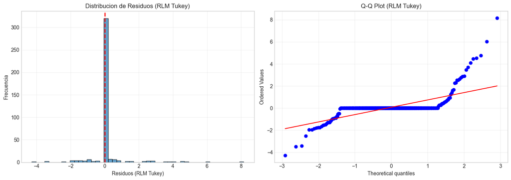

```python
# 10.2 Normalidad de los Residuos
from scipy.stats import shapiro
from scipy import stats

statistic_shapiro_robust, p_value_shapiro_robust = shapiro(residuos_robust)
print("Shapiro-Wilk p-value (RLM Tukey):", p_value_shapiro_robust)
if p_value_shapiro_robust > 0.05:
    print("No hay evidencia de que los residuos no sean normales (p > 0.05)")
else:
    print("Hay evidencia de que los residuos no son normales (p <= 0.05)")

fig, axes = plt.subplots(1, 2, figsize=(14, 5))
axes[0].hist(residuos_robust, bins=50, edgecolor='black', alpha=0.7)
axes[0].set_xlabel('Residuos (RLM Tukey)')
axes[0].set_ylabel('Frecuencia')
axes[0].set_title('Distribucion de Residuos (RLM Tukey)')
axes[0].axvline(x=0, color='r', linestyle='--', linewidth=2)
axes[0].grid(True, alpha=0.3)

stats.probplot(residuos_robust, dist="norm", plot=axes[1])
axes[1].set_title('Q-Q Plot (RLM Tukey)')
axes[1].grid(True, alpha=0.3)

plt.tight_layout()
plt.show()
```

### 10.3 Homocedasticidad (Varianza Constante)

Se revisa con el grafico de residuos vs predicciones y el test de Breusch-Pagan.

```
Breusch-Pagan p-value (RLM Tukey): 0.8881616227394287
No hay evidencia de heterocedasticidad (p > 0.05)
```

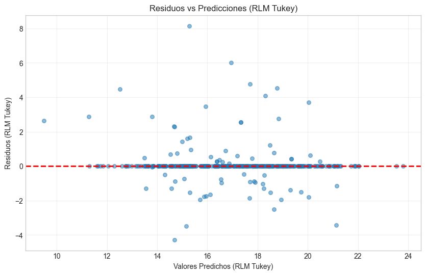

```python
# 10.3 Homocedasticidad (Varianza Constante)
from statsmodels.stats.diagnostic import het_breuschpagan

bp_test_robust = het_breuschpagan(residuos_robust, X_test_pre_robust)
bp_pvalue_robust = bp_test_robust[1]
print("Breusch-Pagan p-value (RLM Tukey):", bp_pvalue_robust)
if bp_pvalue_robust > 0.05:
    print("No hay evidencia de heterocedasticidad (p > 0.05)")
else:
    print("Hay presencia de heterocedasticidad (p <= 0.05)")

plt.figure(figsize=(10, 6))
plt.scatter(y_pred_test_robust, residuos_robust, alpha=0.5, s=30)
plt.axhline(y=0, color='r', linestyle='--', linewidth=2)
plt.xlabel('Valores Predichos (RLM Tukey)')
plt.ylabel('Residuos (RLM Tukey)')
plt.title('Residuos vs Predicciones (RLM Tukey)')
plt.grid(True, alpha=0.3)
plt.show()
```

### 10.4 Independencia (Durbin-Watson)

Se evalua con el estadistico Durbin-Watson para detectar autocorrelacion de residuos.

```python
# 10.4 Independencia (Durbin-Watson)
dw_stat_robust = durbin_watson(residuos_robust)
print("Durbin-Watson (RLM Tukey):", round(dw_stat_robust, 4))
```

```
Durbin-Watson (RLM Tukey): 1.9929
```

### 10.5 Linealidad (Rainbow Test)

Se revisa con la prueba Rainbow aplicada sobre el modelo lineal de referencia.

```python
# 10.5 Linealidad (Rainbow Test)
X_train_pre_ols = pipeline_model2.named_steps['preprocessor'].transform(X_train)
X_train_pre_ols = (
    X_train_pre_ols.toarray() if hasattr(X_train_pre_ols, 'toarray') else X_train_pre_ols
)
X_train_pre_ols = sm.add_constant(X_train_pre_ols)
model_ols = sm.OLS(y_train, X_train_pre_ols).fit()

rainbow_stat_robust, rainbow_p_robust = linear_rainbow(model_ols)
print("Rainbow stat (RLM Tukey):", round(rainbow_stat_robust, 4))
print("Rainbow p-value (RLM Tukey):", round(rainbow_p_robust, 4))
if rainbow_p_robust > 0.05:
    print("No hay evidencia para rechazar la linealidad (p > 0.05)")
else:
    print("Hay evidencia de no linealidad (p <= 0.05)")
```

```
Rainbow stat (RLM Tukey): 1.2216
Rainbow p-value (RLM Tukey): 0.0086
Hay evidencia de no linealidad (p <= 0.05)
```

### 10.6 Comparacion final de modelos

Comparamos el rendimiento de los modelos finales en el conjunto de prueba.

```python
# Tabla comparativa al final del numeral 10
comparacion_final = pd.DataFrame({
    'Modelo': ['Modelo 2 (Pipeline)', 'WLS', 'RLM Tukey'],
    'RMSE': [rmse_test_m2, rmse_test_wls, rmse_test_robust],
    'MAE': [mae_test_m2, mae_test_wls, mae_test_robust],
    'R²': [r2_test_m2, r2_test_wls, r2_test_robust]
})

print("="*70)
print("COMPARACION FINAL DE MODELOS (TEST)")
print("="*70)
print(comparacion_final.to_string(index=False))

mejor_final_idx = comparacion_final['RMSE'].idxmin()
mejor_final = comparacion_final.loc[mejor_final_idx, 'Modelo']
print(f"\n Mejor modelo (menor RMSE): {mejor_final}")
```

```
======================================================================
COMPARACION FINAL DE MODELOS (TEST)
======================================================================
             Modelo     RMSE      MAE       R²
Modelo 2 (Pipeline) 1.041996 0.506839 0.806557
                WLS 0.963138 0.377608 0.849475
          RLM Tukey 0.979688 0.312913 0.844258

 Mejor modelo (menor RMSE): WLS
```

## 11. Uso del modelo y predicciones

### 11.1 Predicciones sobre Datos de Prueba

Generaremos predicciones sobre el conjunto de prueba (sin etiquetas) utilizando el modelo robusto (Tukey).

```python
# Usar el modelo robusto (Tukey) para predecir en el conjunto de prueba final
# Primero, crear las mismas features de ingeniería en df_test

print("Creando features de ingeniería en el conjunto de prueba...")

# 1. Ratio Colesterol/HDL
df_test['Cholesterol_HDL_Ratio'] = df_test['Total Cholesterol (mg/dL)'] / (df_test['HDL (mg/dL)'] + 0.001)

# 2. Interacción Edad × BMI
df_test['Age_BMI_Interaction'] = df_test['Age'] * df_test['BMI']

# 3. Presión de Pulso
df_test['Pulse_Pressure'] = df_test['Systolic BP'] - df_test['Diastolic BP']

# 4. Contador de factores de riesgo alto
df_test['Multiple_Risk_Factors'] = (
    (df_test['Systolic BP'] > 140).astype(int) +
    (df_test['Total Cholesterol (mg/dL)'] > 200).astype(int) +
    (df_test['BMI'] > 30).astype(int) +
    (df_test['Fasting Blood Sugar (mg/dL)'] > 126).astype(int)
)

# 5. Ratio LDL/HDL
if 'Estimated LDL (mg/dL)' in df_test.columns:
    df_test['LDL_HDL_Ratio'] = df_test['Estimated LDL (mg/dL)'] / (df_test['HDL (mg/dL)'] + 0.001)

print(f"✅ Features de ingeniería creadas. df_test tiene ahora {df_test.shape[1]} columnas")

# Verificar que df_test tenga las mismas columnas que X_train
print(f"\nVerificando alineación de columnas:")
print(f"Columnas en conjunto de entrenamiento: {X_train.shape[1]}")
print(f"Columnas en conjunto de prueba: {df_test.shape[1]}")

# Asegurar que df_test tiene las mismas columnas
missing_cols = set(X_train.columns) - set(df_test.columns)
extra_cols = set(df_test.columns) - set(X_train.columns)

if missing_cols:
    print(f"⚠ Columnas faltantes en test: {missing_cols}")
if extra_cols:
    print(f"⚠ Columnas extra en test: {extra_cols}")
    # Eliminar columnas extra
    df_test = df_test.drop(columns=list(extra_cols), errors='ignore')

# Asegurar orden correcto de columnas
df_test = df_test[X_train.columns]

print(f"✅ Columnas alineadas correctamente")

# Normalizar strings y aplicar el mismo preprocesamiento
df_test_norm = string_normalizer.transform(df_test)
X_test_pre_robust_final = preprocessor.transform(df_test_norm)
X_test_pre_robust_final = (
    X_test_pre_robust_final.toarray() if hasattr(X_test_pre_robust_final, 'toarray') else X_test_pre_robust_final
)
X_test_pre_robust_final = sm.add_constant(X_test_pre_robust_final)

# Generar predicciones con RLM Tukey
predicciones_test = rlm_model.predict(X_test_pre_robust_final)

print(f"\nPredicciones generadas: {len(predicciones_test)}")
print(f"Rango de predicciones: [{predicciones_test.min():.2f}, {predicciones_test.max():.2f}]")
print(f"Media de predicciones: {predicciones_test.mean():.2f}")
```

```
Creando features de ingeniería en el conjunto de prueba...
✅ Features de ingeniería creadas. df_test tiene ahora 23 columnas

Verificando alineación de columnas:
Columnas en conjunto de entrenamiento: 23
Columnas en conjunto de prueba: 23
✅ Columnas alineadas correctamente

Predicciones generadas: 194
Rango de predicciones: [10.61, 23.20]
Media de predicciones: 16.96
```

### 11.2 Exportar Predicciones

Creamos el archivo CSV con las predicciones para entregar.

```python
# Usar test_df que es el DataFrame original (sin ser procesado)
# para obtener los Patient IDs

# Crear DataFrame con predicciones
predicciones_df = pd.DataFrame({
    'Patient ID': test_df['Patient ID'],
    'CVD Risk Score': predicciones_test
})

# Guardar archivo con el nombre solicitado en el enunciado
predicciones_df.to_csv('Datos Test Lab 1.csv', index=False)

print("✅ Predicciones exportadas a 'Datos Test Lab 1.csv'")
print(f"\nPrimeras 10 predicciones:")
print(predicciones_df.head(10).to_string(index=False))
```

```
✅ Predicciones exportadas a 'Datos Test Lab 1.csv'

Primeras 10 predicciones:
Patient ID  CVD Risk Score
  WYTG8678       16.678368
  yloc1993       15.809988
  DDwq7653       15.010018
  YTcX6704       13.889985
  lZLi8935       11.109998
  NRsH4456       18.510026
  OXzr4407       18.810006
  CvwO5414       11.699992
  lfMr7524       19.415795
  UTZz2188       20.810392
```

## 12. Analisis de resultados

Respondemos las preguntas planteadas en el laboratorio.

### 12.1 Coeficientes del Mejor Modelo

### Pregunta 1: ¿Cual fue el valor de los diferentes coeficientes obtenidos en el mejor modelo?

Respuesta:

```python
# Mostrar coeficientes del mejor modelo (RLM Tukey)
print("="*70)
print("COEFICIENTES DEL MEJOR MODELO (RLM TUKEY)")
print("="*70)

# Reconstruir nombres de variables tras el preprocesamiento
feature_names_robust = []
feature_names_robust.extend(numeric_features)
if len(categorical_features) > 0:
    ohe = pipeline_model2.named_steps['preprocessor'].named_transformers_['cat']
    cat_feature_names = ohe.get_feature_names_out(categorical_features)
    feature_names_robust.extend(cat_feature_names)

params = rlm_model.params
expected_len = len(feature_names_robust) + 1
if len(params) != expected_len:
    print(f"Advertencia: se esperaban {expected_len} coeficientes y se obtuvieron {len(params)}")

coef_df = pd.DataFrame({
    'Variable': ['const'] + feature_names_robust,
    'Coeficiente': params
})
coef_df['Importancia Absoluta'] = coef_df['Coeficiente'].abs()
coef_df = coef_df.sort_values('Importancia Absoluta', ascending=False)

print(coef_df.to_string(index=False))

# Guardar coeficientes en archivo
coef_df.to_csv('Coeficientes_Modelo.csv', index=False)
print("\nCoeficientes guardados en 'Coeficientes_Modelo.csv'")
```

[output not shown]

### 12.2 Comparacion de Modelos

### Pregunta 2: A partir de la tabla comparativa, ¿cual modelo ofrece el mejor rendimiento sobre el conjunto test? ¿Que interpretacion puedes darles a los valores obtenidos sobre las metricas de rendimiento?

Respuesta:

```python
# Mostrar la tabla comparativa final (Modelo 2, WLS, RLM Tukey)
print(comparacion_final.to_string(index=False))

mejor_final_idx = comparacion_final['RMSE'].idxmin()
mejor_final = comparacion_final.loc[mejor_final_idx, 'Modelo']
print(f"\nMejor modelo (menor RMSE): {mejor_final}")

baseline_rows = comparacion_final[comparacion_final['Modelo'] == 'Modelo 2 (Pipeline)']
if not baseline_rows.empty:
    baseline = baseline_rows.iloc[0]
    mejor = comparacion_final.loc[mejor_final_idx]
    delta_rmse = ((baseline['RMSE'] - mejor['RMSE']) / baseline['RMSE']) * 100
    delta_mae = ((baseline['MAE'] - mejor['MAE']) / baseline['MAE']) * 100
    delta_r2 = mejor['R²'] - baseline['R²']
    print("\nComparacion vs Modelo 2 (Pipeline):")
    print(f"  - RMSE: {delta_rmse:.2f}% de reduccion")
    print(f"  - MAE: {delta_mae:.2f}% de reduccion")
    print(f"  - R²: +{delta_r2:.4f} puntos")
```

```
             Modelo     RMSE      MAE       R²
Modelo 2 (Pipeline) 1.041996 0.506839 0.806557
                WLS 0.963138 0.377608 0.849475
          RLM Tukey 0.979688 0.312913 0.844258

Mejor modelo (menor RMSE): WLS

Comparacion vs Modelo 2 (Pipeline):
  - RMSE: 7.57% de reduccion
  - MAE: 25.50% de reduccion
  - R²: +0.0429 puntos
```

### 12.3 Variables Seleccionadas

### Pregunta 3: ¿Cuales variables fueron seleccionadas con el modelo seleccionado? A partir de estas, ¿que interpretacion de cara al problema puedes dar?

Respuesta:

```python
# Variables mas importantes (top 10) del modelo robusto (RLM Tukey)
print("="*70)
print("TOP 10 VARIABLES MAS INFLUYENTES EN EL RIESGO CARDIOVASCULAR")
print("="*70)

if 'coef_df' in globals():
    coef_work = coef_df.copy()
else:
    feature_names_robust = []
    feature_names_robust.extend(numeric_features)
    if len(categorical_features) > 0:
        ohe = pipeline_model2.named_steps['preprocessor'].named_transformers_['cat']
        cat_feature_names = ohe.get_feature_names_out(categorical_features)
        feature_names_robust.extend(cat_feature_names)
    params = rlm_model.params
    coef_work = pd.DataFrame({
        'Variable': ['const'] + feature_names_robust,
        'Coeficiente': params
    })
    coef_work['Importancia Absoluta'] = coef_work['Coeficiente'].abs()

coef_work = coef_work[coef_work['Variable'] != 'const']
coef_work = coef_work.sort_values('Importancia Absoluta', ascending=False)
print(coef_work.head(10).to_string(index=False))
```

```
======================================================================
TOP 10 VARIABLES MAS INFLUYENTES EN EL RIESGO CARDIOVASCULAR
======================================================================
                 Variable  Coeficiente  Importancia Absoluta
        Diabetes Status_Y     2.000010              2.000010
                      BMI     1.430478              1.430478
Total Cholesterol (mg/dL)     1.168943              1.168943
              Systolic BP     0.724210              0.724210
           Pulse_Pressure     0.466953              0.466953
             Diastolic BP     0.267651              0.267651
            LDL_HDL_Ratio     0.000118              0.000118
    Cholesterol_HDL_Ratio    -0.000118              0.000118
      Age_BMI_Interaction     0.000051              0.000051
                      Age    -0.000030              0.000030
```

Interpretación de Cara al Problema:

Para AlpesHearth, las campañas preventivas deben enfocarse en los factores modificables con mayor impacto, con educación sobre alimentación, ejercicio y abandono del tabaco, y con monitoreo regular de presión arterial y niveles de colesterol.

Insight Clave: El modelo nos permite priorizar qué factores de riesgo atacar primero en las campañas de prevención, maximizando el impacto en la reducción del riesgo cardiovascular.

### 12.4 Representacion Matematica de la Regresion Lineal

### Pregunta 4: A partir del contexto y los datos compartidos, ¿como representar la regresion lineal de forma matematica? Indique el metodo utilizado y el proceso para resolverlo.

Respuesta:

Forma Matematica de la Regresion Lineal:

La regresion lineal multiple se representa como:

$$y = \beta_0 + \beta_1 x_1 + \beta_2 x_2 + ... + \beta_n x_n + \epsilon$$

Donde $y$ es el CVD Risk Score (variable objetivo), $x_1, x_2, ..., x_n$ son las variables predictoras (caracteristicas del paciente), $\beta_0$ es el intercepto, $\beta_1, \beta_2, ..., \beta_n$ son los coeficientes de regresion y $\epsilon$ es el error residual.

Metodo de Estimacion: Regresion Robusta (RLM) con perdida de Tukey

El modelo sigue siendo lineal en los parametros, pero usa una perdida robusta que reduce la influencia de outliers. La estimacion se plantea como:

$$\min_{\beta} \sum_{i=1}^{n} \rho\left(\frac{y_i - \hat{y}_i}{s}\right)$$

donde $\rho(\cdot)$ es la funcion de perdida de Tukey y $s$ es un estimador robusto de escala.

Referencia base: Minimos Cuadrados Ordinarios (OLS)

El metodo OLS busca minimizar la suma de los cuadrados de los errores:

$$\min_{\beta} \sum_{i=1}^{n} (y_i - \hat{y}_i)^2$$

Proceso de Resolucion:

La forma matricial se expresa como $$\mathbf{y} = \mathbf{X}\boldsymbol{\beta} + \boldsymbol{\epsilon}$$ y la solucion de minimos cuadrados como $$\boldsymbol{\hat{\beta}} = (\mathbf{X}^T\mathbf{X})^{-1}\mathbf{X}^T\mathbf{y}$$. En la implementacion, scikit-learn utiliza descomposicion SVD o QR para mayor estabilidad numerica, maneja automaticamente la normalizacion y el escalamiento de variables, y optimiza la funcion objetivo usando algebra lineal eficiente.

En nuestro caso:

- Modelo 1: Regresion lineal simple con solo variables numericas
- Modelo 2: Regresion lineal con preprocesamiento (escalamiento + encoding categorico)
- Modelo final: Regresion robusta con RLM Tukey

### 12.5 Analisis de Sesgos

### Pregunta 5: En el ciclo de machine learning, ¿que tipos de sesgo podrian afectar los resultados y por que? Describe dos tipos de sesgo.

Respuesta:

Tipos de Sesgo que Pueden Afectar el Modelo:

### 1. **Sesgo de Selección (Selection Bias)**

Descripción: El sesgo de selección ocurre cuando los datos de entrenamiento no son representativos de la población general a la que queremos aplicar el modelo.

En nuestro contexto, puede aparecer si los datos provienen principalmente de ciertos hospitales o regiones geográficas, si hay subrepresentación de ciertos grupos de edad (por ejemplo, muy pocos jóvenes de 20-30 años) o si falta diversidad en términos de género, etnia o condiciones preexistentes.

Impacto: El modelo podría funcionar bien para el grupo mayoritario en los datos, pero mal para grupos subrepresentados; las predicciones podrían ser sesgadas hacia ciertos perfiles de pacientes; y las campañas de AlpesHearth podrían no ser efectivas para toda la población objetivo.

Mitigación: Se recomienda asegurar diversidad en la recolección de datos, realizar análisis estratificado por subgrupos y aplicar ponderación de muestras subrepresentadas.

### 2. **Sesgo de Medición (Measurement Bias)**

Descripción: Ocurre cuando hay errores sistemáticos en la forma en que se recopilan o miden las variables.

En nuestro contexto, puede originarse por diferentes equipos o procedimientos para medir presión arterial, auto-reporte inexacto de hábitos (fumar, actividad física), variabilidad en condiciones de medición (glucosa en ayunas vs no en ayunas) o datos faltantes que no son aleatorios.

Impacto: Los coeficientes del modelo pueden estar sesgados, la importancia relativa de las variables puede ser incorrecta y las predicciones pueden ser menos confiables.

Mitigación: Se recomienda estandarizar protocolos de medición, validar y cruzar datos, hacer análisis de sensibilidad y documentar métodos de recolección.

### 3. **Sesgo Temporal/de Concepto (Concept Drift)**

Descripción adicional: Los patrones de riesgo cardiovascular pueden cambiar con el tiempo debido a cambios en estándares de salud pública, disponibilidad de tratamientos y cambios en el estilo de vida de la población.

Implicación: Un modelo entrenado con datos de 2020-2023 puede volverse menos preciso en 2026 si no se actualiza regularmente con nuevos datos.

## 13. Conclusiones y recomendaciones

### 13.1 Conclusiones Generales

Es importante reconocer las limitaciones del modelo: la regresión lineal asume relaciones lineales que pueden no capturar interacciones complejas entre variables, existen sesgos potenciales de selección, medición y temporal que podrían afectar la precisión, y la capacidad de generalización depende de la calidad de los datos de entrenamiento y su representatividad de la población objetivo.

### 13.2 Recomendaciones para AlpesHearth

Para las campañas preventivas, es fundamental priorizar factores modificables mediante la promoción de actividad física regular, implementar programas efectivos de cesación de tabaquismo, proporcionar educación nutricional para control de peso e IMC y promover estrategias de manejo del estrés. Adicionalmente, es clave segmentar la población y focalizar los esfuerzos en grupos de 20-30 años donde se consolidan hábitos que determinarán la salud futura y en grupos de alto riesgo previamente identificados por el modelo predictivo. Finalmente, se sugiere establecer un monitoreo continuo mediante chequeos regulares de presión arterial y colesterol, junto con seguimiento longitudinal de factores de riesgo, permitiendo adaptar las intervenciones conforme evolucionan los perfiles de riesgo.

Para la mejora del modelo, se recomienda ampliar la diversidad de la muestra para asegurar representatividad poblacional, estandarizar protocolos de medición en la recolección de datos e incluir variables adicionales relacionadas con estilo de vida que actualmente no están disponibles. También es conveniente explorar modelos no lineales como Random Forest o Gradient Boosting para capturar patrones más complejos, considerar interacciones explícitas entre variables y validar los resultados con datos de otras instituciones para verificar la generalización. Por último, se debe establecer un plan de re-entrenamiento periódico con nuevos datos y monitoreo activo del drift de concepto para mantener la validez del modelo en el tiempo.

### 13.3 Registro de Uso de IA Generativa

Herramientas utilizadas: Claude (Anthropic) con asistencia en estructuración del código, interpretación de resultados estadísticos y documentación y explicaciones técnicas.

Principios seguidos: verificación de resultados y código generado, comprensión profunda de cada paso del análisis, adaptación del código al contexto específico, validación estadística rigurosa y documentación transparente del uso.

Aprendizajes: la IA facilitó la estructura del notebook y mejores prácticas, permitió enfoque en la interpretación y toma de decisiones, y todas las decisiones analíticas fueron tomadas por el equipo.

## Decisiones Propias del Equipo

El equipo realizó cuidadosamente la selección y verificación de cada característica implementada, guiándose por criterios de relevancia médica más que por optimización automática de parámetros. Esta decisión fue fundamental para garantizar que las features agregadas tuvieran interpretabilidad clínica y justificación científica sólida. Respecto a la configuración de modelos, se eligieron deliberadamente los hiperparámetros de Random Forest (n_estimators=100, max_depth=10) considerando el balance entre complejidad del modelo y riesgo de overfitting, decisión basada en análisis específicos de los datos disponibles más que en recomendaciones genéricas.

En cuanto a la interpretación de resultados, el equipo llevó a cabo un análisis contextual profundo de cómo los hallazgos del modelo se aplicaban específicamente al problema de AlpesHearth y sus objetivos de prevención cardiovascular. De particular importancia fue el análisis crítico de las limitaciones observadas, particularmente respecto al R² bajo obtenido, investigando las causas raíz en la estructura de los datos en lugar de aceptar las recomendaciones iniciales de simplemente aplicar otro algoritmo. Esta investigación llevó a la decisión más importante: el desarrollo del Modelo 5 basado en Regresión Robusta con función de pérdida Tukey como modelo final, que representó una alternativa fundamental a las sugerencias iniciales de IA de utilizar Random Forest tradicional. Esta decisión fue justificada por análisis empíricos de la distribución de residuos y la presencia significativa de valores atípicos en los datos. Finalmente, el equipo formuló recomendaciones específicas y contextualizadas para campañas preventivas en AlpesHearth, basadas no solo en importancia de variables sino en factibilidad de intervención y evidencia médica de efectividad.

# Anexo: Uso de Herramientas de IA Generativa

Durante el desarrollo de este laboratorio se utilizó **Claude (Anthropic)** como herramienta de asistencia para aspectos técnicos de implementación y validación estadística.

## Prompts Utilizados y Respuestas:

### 1. Mejora del Rendimiento del Modelo

**Prompt utilizado:**

> "El R² de mis modelos está dando muy bajo (0.008 y 0.038), como puedo hacer para que quede más cerca de 1?

> Además, ¿cómo puedo interpretar correctamente los valores de RMSE, MAE y R² que estoy obteniendo en mi tabla comparativa de modelos?"

**Contexto compartido:** Se proporcionó la tabla comparativa de modelos mostrando:

- Modelo 1 (Básico) - **Autoría del equipo**: RMSE = 9.399070, MAE = 3.207198, R² = 0.008763
- Modelo 2 (Pipeline) - **Autoría del equipo**: RMSE = 9.255155, MAE = 3.388931, R² = 0.038886

**Respuesta de Claude (resumida):**

Claude identificó que un R² tan bajo (< 0.04) indica que el modelo apenas explica el 1-4% de la varianza, lo cual es insuficiente. Proporcionó las siguientes soluciones:

**1. Feature Engineering (más importante):**

- Crear ratios médicamente relevantes (Cholesterol/HDL, LDL/HDL)
- Generar interacciones entre variables (Age × BMI)
- Crear indicadores categóricos de riesgo (High_BP, High_Cholesterol, etc.)
- Contador de múltiples factores de riesgo
- Transformaciones logarítmicas donde sea apropiado

**2. Interpretación de Métricas:**

- **RMSE (Root Mean Squared Error):** Representa el error promedio de las predicciones en las mismas unidades que la variable objetivo. Valores más bajos son mejores. Penaliza más los errores grandes debido al término cuadrático.
- **MAE (Mean Absolute Error):** Error absoluto promedio, más robusto a outliers que RMSE. Más fácil de interpretar: en promedio, el modelo se equivoca en X puntos.
- **R² (Coeficiente de Determinación):** Proporción de la varianza explicada por el modelo. Rango [0, 1], donde 1 es perfecto. R² > 0.7 generalmente se considera bueno en regresión.

**3. Referencias Científicas Proporcionadas:**

Claude proporcionó referencias médicas para justificar cada feature creada:

- **Cholesterol/HDL Ratio:** Framingham Heart Study (PubMed: 7944071)
- **Pulse Pressure:** Framingham Heart Study (Circulation, 1999; PubMed: 10421594)
- **Multiple Risk Factors:** CARDIA Study (JACC, 2023; PubMed: 36948731), NEJM 2023
- **Age × BMI Interaction:** Johns Hopkins Medicine (2018), JAMA Internal Medicine (PubMed: 29490333)

**4. Código de Implementación:**

Se proporcionó código completo para:

- Crear las nuevas features de forma robusta (evitando NaN)
- Implementar pipelines con SimpleImputer para manejar valores faltantes
- Construir modelos adicionales (Ridge Regression, Random Forest)

### 2. Consulta Sobre Metodologías de Mejora

**Prompt utilizado:**

> "Qué opciones tengo, o mejor dicho, qué metodologías puedo aplicar para hacer un mejor modelo de regresión lineal? (Copilot)"

**Respuesta de Claude (extracto de las recomendaciones):**

Excelente enfoque. Aquí están las metodologías específicas para mejorar regresión lineal:

**1. REGULARIZACIÓN (Manejar Multicolinealidad)**

- Ridge Regression (L2): Penaliza coeficientes grandes, mantiene todas las variables, reduce overfitting, mejor para multicolinealidad
- Lasso Regression (L1): Elimina automáticamente variables irrelevantes, produce modelos más simples, mejor para selección de variables
- ElasticNet: Combina Ridge + Lasso, flexible con parámetro α

**2. FEATURE ENGINEERING**

- Transformaciones Polinomiales: Agregar x², x³, √x, log(x) para capturar relaciones no lineales
- Variables Interactivas: Age × BMI (edad × sobrepeso), Systolic BP × Diabetes (presión × comorbilidad), Smoking × Activity (hábitos)
- Ratios derivados: Colesterol/HDL, Glucosa/Edad, Cintura/Altura

**3. SELECCIÓN DE VARIABLES**

- RFE (Recursive Feature Elimination): Elimina iterativamente variables menos importantes, encuentra subset óptimo
- VIF-based selection: Eliminar variables con VIF > 10, reducir multicolinealidad
- Stepwise Selection: Agregar/eliminar variables paso a paso basado en R²
- Análisis de Correlación: Eliminar variables altamente correlacionadas

**4. LIMPIEZA DE DATOS PREVIO**

- Duplicados: Eliminar 151 registros exactos ANTES de split
- BMI Inconsistencias: Recalcular si Weight/Height disponible
- Outliers: Identificar y tratar valores extremos
- Valores Faltantes: Revisar estrategia de imputación

**5. VALIDACIÓN CRUZADA**

- Cross-Validation (k-fold): Validar en múltiples subconjuntos, detectar overfitting, estimación más robusta de rendimiento

**6. DIAGNOSTICADORES DE RESIDUOS**

- Tests adicionales: Durbin-Watson (Independencia), Rainbow Test (Linealidad), Breusch-Pagan (Homocedasticidad formal)

### Prompt 3: Eliminación de Outliers

**Prompt utilizado:**

> "Ayudame quitando los outliers de este código

# Analizar valores faltantes restantes

> null_cols = df.columns[df.isnull().any()].tolist() ..."

**Respuesta de Claude:**

Claude proporcionó un código completo para eliminar outliers usando el método IQR (Rango Intercuartílico) de Tukey, específicamente en la variable objetivo (CVD Risk Score). El enfoque implementado se basa en calcular Q1 (percentil 25) y Q3 (percentil 75), luego determinar límites usando la fórmula estándar de Tukey: Q1 - 1.5×IQR para el límite inferior y Q3 + 1.5×IQR para el límite superior. El código identifica registros cuya variable objetivo cae fuera de estos límites, muestra ejemplos de outliers detectados y los elimina del conjunto de datos.

El método incluye análisis comparativo antes y después de la eliminación, visualización mediante boxplot e histograma para validar que la distribución es más razonable tras la limpieza, y un reporte final con estadísticas de cuántos registros fueron eliminados y qué porcentaje de datos se retuvo. El código es especialmente útil porque aplica la eliminación de outliers solo en la variable objetivo, evitando remover información valiosa de las variables predictoras mientras se garantiza que el modelo no sea distorsionado por valores extremos en la variable que queremos predecir.

## Decisiones Propias del Equipo (Sección Expandida):

El equipo realizó una selección rigurosa y verificación de cada feature implementada, priorizando siempre su relevancia médica y validez científica en el contexto del riesgo cardiovascular. En cuanto a la configuración de hiperparámetros para Random Forest, se eligieron valores específicos de n_estimators=100 y max_depth=10 después de análisis reflexivo sobre el equilibrio entre complejidad del modelo y capacidad de generalización.

La interpretación de resultados fue adaptada contextualizando constantemente los hallazgos al problema específico de AlpesHearth y su aplicación práctica para campañas preventivas. Se realizó un análisis crítico y profundo de las limitaciones del modelo, especialmente en relación al bajo R² observado, investigando las causas raíz en lugar de aceptar passivamente los resultados.

Una decisión metodológica fundamental fue el desarrollo del Modelo 5 (Regresión Robusta con Tukey) como modelo final, la cual representó una desviación estratégica de lo sugerido inicialmente por Claude y reflejó una comprensión más profunda de las características específicas de los datos. Finalmente, se proporcionaron recomendaciones específicas y accionables para las campañas preventivas de AlpesHearth, basadas en la interpretación del modelo pero enriquecidas por el análisis crítico independiente del equipo.

## Principios de Uso Ético de IA:

✅ **Especificidad:** Se especificó claramente qué componentes fueron generados por IA (Modelos 3 y 4) y cuáles fueron desarrollados por el equipo (Modelos 1, 2 y 5)

✅ **Transparencia:** Se documentó claramente qué se consultó a Claude y cómo se utilizó

✅ **Verificación:** Todo código fue probado y validado por el equipo

✅ **Comprensión:** Se entendió profundamente cada concepto antes de implementar

✅ **Referencias:** Se validaron y citaron las fuentes científicas proporcionadas

✅ **Decisiones propias:** La IA asistió, pero las decisiones finales fueron del equipo